# Máster en Data Science - Machine Learning

# Procesamiento de variables: Codificación de variables categóricas y escalado

Autor: Ramón Morillo Barrera

## Dataset: Application data

En este notebook trabajaremos en el procesamiento de nuestras variables categóricas del Dataset, con el objetivo de que queden listas para ser procesadas por los modelos que probaremos.

Aplicaré diferentes técnicas de encoding que transforman las variables categóricas de nuestro Dataset a numéricas y posteriormente permitirán a los modelos que implementemos procesar las variables categóricas presentes en nuestro Dataset. Además de un escalado de variables.

El escalado de variables es un proceso de transformar los datos para que todas las características estén en la misma escala, generalmente normalizando los valores dentro de un rango (por ejemplo, 0 a 1) o estandarizándolos para que tengan media 0 y desviación estándar 1. Esto evita que las variables con mayores rangos predominen en el modelo o afecten a los cálculos del mismo, especialmente en algoritmos basados en distancia (como SVM, KNN, PCA) o gradientes (como redes neuronales). Además, mejora el desempeño ya que haace que algoritmos sensibles a la magnitud de las variables (por ejemplo, KNN) funcionen mejor y evita sesgos haciendo que las variables con grandes rangos no tendrán mayor peso que otras menos dispersas.

#### Librerías

```python
import sys
import pandas as pd
import numpy as np
import sklearn
from sklearn.pipeline import Pipeline
from sklearn import metrics
# pip install category-encoders
import category_encoders as ce
from sklearn.preprocessing import OneHotEncoder
from sklearn.ensemble import GradientBoostingClassifier
import matplotlib.pyplot as plt
import seaborn as sns
from sklearn.ensemble import RandomForestClassifier, AdaBoostClassifier
from sklearn.preprocessing import StandardScaler

from sklearn.metrics import classification_report, confusion_matrix, roc_curve, auc, \
                            silhouette_score, recall_score, precision_score, make_scorer, \
                            roc_auc_score, f1_score, precision_recall_curve, accuracy_score, roc_auc_score, \
                            classification_report, confusion_matrix, calinski_harabasz_score, silhouette_samples

from sklearn import metrics
from sklearn.metrics import ConfusionMatrixDisplay

from sklearn.model_selection import train_test_split
from sklearn.tree import DecisionTreeClassifier
from sklearn.linear_model import Lasso, LogisticRegression
from sklearn.feature_selection import SelectFromModel, RFE
from sklearn.manifold import TSNE
from sklearn.decomposition import PCA
from sklearn.cluster import KMeans
from boruta import BorutaPy
from sklearn.compose import ColumnTransformer
from sklearn.pipeline import Pipeline
from category_encoders import TargetEncoder, CatBoostEncoder

import pickle
from joblib import dump, load

import warnings
warnings.filterwarnings('ignore')

pd.set_option('display.max_columns', 500)
pd.set_option('display.max_rows', 500)
```

#### Funciones

```python
sys.path.append('../src')
import funciones_auxiliares as f_aux
sys.path.remove('../src')

# Constante
seed = 12354
```

#### Importación de datos

```python
df_loan_train = pd.read_csv("../../data_loan_status/interim/data_split/df_loan_train.csv")
df_loan_test = pd.read_csv("../../data_loan_status/interim/data_split/df_loan_test.csv")
```

```python
df_loan_train.head()
```

|  | SK_ID_CURR | COMMONAREA_AVG | COMMONAREA_MEDI | COMMONAREA_MODE | NONLIVINGAPARTMENTS_AVG | NONLIVINGAPARTMENTS_MEDI | NONLIVINGAPARTMENTS_MODE | FONDKAPREMONT_MODE | LIVINGAPARTMENTS_MEDI | LIVINGAPARTMENTS_AVG | LIVINGAPARTMENTS_MODE | FLOORSMIN_MODE | FLOORSMIN_AVG | FLOORSMIN_MEDI | YEARS_BUILD_MODE | YEARS_BUILD_MEDI | YEARS_BUILD_AVG | OWN_CAR_AGE | LANDAREA_MEDI | LANDAREA_AVG | LANDAREA_MODE | BASEMENTAREA_MODE | BASEMENTAREA_AVG | BASEMENTAREA_MEDI | EXT_SOURCE_1 | NONLIVINGAREA_AVG | NONLIVINGAREA_MODE | NONLIVINGAREA_MEDI | ELEVATORS_MEDI | … |
| --- | --- | --- | --- | --- | --- | --- | --- | --- | --- | --- | --- | --- | --- | --- | --- | --- | --- | --- | --- | --- | --- | --- | --- | --- | --- | --- | --- | --- | --- | --- |
| 0 | 189359 | 0.0210 | 0.0208 | 0.0190 | 0.0 | 0.0 | 0.0 | Desconocido | 0.0761 | 0.0756 | 0.0771 | 0.2083 | 0.2083 | 0.2083 | 0.7648 | 0.7585 | 0.7552 | 3.0 | 0.0487 | 0.0482 | 0.0459 | 0.0746 | 0.0763 | 0.0759 | 0.270597 | 0.1658 | 0.1755 | 0.1693 | 0.32 | … |
| 1 | 418867 | 0.0142 | 0.0142 | 0.0143 | 0.0 | 0.0 | 0.0 | reg oper account | 0.0770 | 0.0756 | 0.0826 | 0.2083 | 0.2083 | 0.2083 | 0.7648 | 0.7585 | 0.7552 | 9.0 | 0.0639 | 0.0629 | 0.0643 | 0.0794 | 0.0765 | 0.0765 | 0.232782 | 0.0000 | 0.0000 | 0.0000 | 0.00 | … |
| 2 | 263377 | 0.0210 | 0.0208 | 0.0190 | 0.0 | 0.0 | 0.0 | Desconocido | 0.0761 | 0.0756 | 0.0771 | 0.2083 | 0.2083 | 0.2083 | 0.7648 | 0.7585 | 0.7552 | 6.0 | 0.0487 | 0.0482 | 0.0459 | 0.0746 | 0.0763 | 0.0759 | 0.505892 | 0.0036 | 0.0011 | 0.0030 | 0.00 | … |
| 3 | 366006 | 0.0210 | 0.0208 | 0.0190 | 0.0 | 0.0 | 0.0 | Desconocido | 0.0761 | 0.0756 | 0.0771 | 0.2083 | 0.2083 | 0.2083 | 0.7648 | 0.7585 | 0.7552 | 9.0 | 0.0487 | 0.0482 | 0.0459 | 0.1902 | 0.1833 | 0.1833 | 0.505892 | 0.0362 | 0.0383 | 0.0369 | 0.28 | … |
| 4 | 197882 | 0.0210 | 0.0208 | 0.0190 | 0.0 | 0.0 | 0.0 | Desconocido | 0.0761 | 0.0756 | 0.0771 | 0.2083 | 0.2083 | 0.2083 | 0.7648 | 0.7585 | 0.7552 | 9.0 | 0.0487 | 0.0482 | 0.0459 | 0.0746 | 0.0763 | 0.0759 | 0.505892 | 0.0036 | 0.0011 | 0.0030 | 0.00 | … |

```python
df_loan_train.columns
```

```
Index(['SK_ID_CURR', 'COMMONAREA_AVG', 'COMMONAREA_MEDI', 'COMMONAREA_MODE',
       'NONLIVINGAPARTMENTS_AVG', 'NONLIVINGAPARTMENTS_MEDI',
       'NONLIVINGAPARTMENTS_MODE', 'FONDKAPREMONT_MODE',
       'LIVINGAPARTMENTS_MEDI', 'LIVINGAPARTMENTS_AVG',
       ...
       'FLAG_DOCUMENT_13', 'FLAG_DOCUMENT_19', 'FLAG_DOCUMENT_18',
       'FLAG_DOCUMENT_17', 'FLAG_DOCUMENT_16', 'FLAG_DOCUMENT_15',
       'FLAG_DOCUMENT_14', 'FLAG_DOCUMENT_20', 'FLAG_DOCUMENT_21', 'TARGET'],
      dtype='object', length=122)
```

```python
df_loan_train.head()
```

|  | SK_ID_CURR | COMMONAREA_AVG | COMMONAREA_MEDI | COMMONAREA_MODE | NONLIVINGAPARTMENTS_AVG | NONLIVINGAPARTMENTS_MEDI | NONLIVINGAPARTMENTS_MODE | FONDKAPREMONT_MODE | LIVINGAPARTMENTS_MEDI | LIVINGAPARTMENTS_AVG | LIVINGAPARTMENTS_MODE | FLOORSMIN_MODE | FLOORSMIN_AVG | FLOORSMIN_MEDI | YEARS_BUILD_MODE | YEARS_BUILD_MEDI | YEARS_BUILD_AVG | OWN_CAR_AGE | LANDAREA_MEDI | LANDAREA_AVG | LANDAREA_MODE | BASEMENTAREA_MODE | BASEMENTAREA_AVG | BASEMENTAREA_MEDI | EXT_SOURCE_1 | NONLIVINGAREA_AVG | NONLIVINGAREA_MODE | NONLIVINGAREA_MEDI | ELEVATORS_MEDI | … |
| --- | --- | --- | --- | --- | --- | --- | --- | --- | --- | --- | --- | --- | --- | --- | --- | --- | --- | --- | --- | --- | --- | --- | --- | --- | --- | --- | --- | --- | --- | --- |
| 0 | 189359 | 0.0210 | 0.0208 | 0.0190 | 0.0 | 0.0 | 0.0 | Desconocido | 0.0761 | 0.0756 | 0.0771 | 0.2083 | 0.2083 | 0.2083 | 0.7648 | 0.7585 | 0.7552 | 3.0 | 0.0487 | 0.0482 | 0.0459 | 0.0746 | 0.0763 | 0.0759 | 0.270597 | 0.1658 | 0.1755 | 0.1693 | 0.32 | … |
| 1 | 418867 | 0.0142 | 0.0142 | 0.0143 | 0.0 | 0.0 | 0.0 | reg oper account | 0.0770 | 0.0756 | 0.0826 | 0.2083 | 0.2083 | 0.2083 | 0.7648 | 0.7585 | 0.7552 | 9.0 | 0.0639 | 0.0629 | 0.0643 | 0.0794 | 0.0765 | 0.0765 | 0.232782 | 0.0000 | 0.0000 | 0.0000 | 0.00 | … |
| 2 | 263377 | 0.0210 | 0.0208 | 0.0190 | 0.0 | 0.0 | 0.0 | Desconocido | 0.0761 | 0.0756 | 0.0771 | 0.2083 | 0.2083 | 0.2083 | 0.7648 | 0.7585 | 0.7552 | 6.0 | 0.0487 | 0.0482 | 0.0459 | 0.0746 | 0.0763 | 0.0759 | 0.505892 | 0.0036 | 0.0011 | 0.0030 | 0.00 | … |
| 3 | 366006 | 0.0210 | 0.0208 | 0.0190 | 0.0 | 0.0 | 0.0 | Desconocido | 0.0761 | 0.0756 | 0.0771 | 0.2083 | 0.2083 | 0.2083 | 0.7648 | 0.7585 | 0.7552 | 9.0 | 0.0487 | 0.0482 | 0.0459 | 0.1902 | 0.1833 | 0.1833 | 0.505892 | 0.0362 | 0.0383 | 0.0369 | 0.28 | … |
| 4 | 197882 | 0.0210 | 0.0208 | 0.0190 | 0.0 | 0.0 | 0.0 | Desconocido | 0.0761 | 0.0756 | 0.0771 | 0.2083 | 0.2083 | 0.2083 | 0.7648 | 0.7585 | 0.7552 | 9.0 | 0.0487 | 0.0482 | 0.0459 | 0.0746 | 0.0763 | 0.0759 | 0.505892 | 0.0036 | 0.0011 | 0.0030 | 0.00 | … |

```python
df_loan_train.describe()
```

|  | SK_ID_CURR | COMMONAREA_AVG | COMMONAREA_MEDI | COMMONAREA_MODE | NONLIVINGAPARTMENTS_AVG | NONLIVINGAPARTMENTS_MEDI | NONLIVINGAPARTMENTS_MODE | LIVINGAPARTMENTS_MEDI | LIVINGAPARTMENTS_AVG | LIVINGAPARTMENTS_MODE | FLOORSMIN_MODE | FLOORSMIN_AVG | FLOORSMIN_MEDI | YEARS_BUILD_MODE | YEARS_BUILD_MEDI | YEARS_BUILD_AVG | OWN_CAR_AGE | LANDAREA_MEDI | LANDAREA_AVG | LANDAREA_MODE | BASEMENTAREA_MODE | BASEMENTAREA_AVG | BASEMENTAREA_MEDI | EXT_SOURCE_1 | NONLIVINGAREA_AVG | NONLIVINGAREA_MODE | NONLIVINGAREA_MEDI | ELEVATORS_MEDI | ELEVATORS_AVG | … |
| --- | --- | --- | --- | --- | --- | --- | --- | --- | --- | --- | --- | --- | --- | --- | --- | --- | --- | --- | --- | --- | --- | --- | --- | --- | --- | --- | --- | --- | --- | --- |
| count | 246008.000000 | 246008.000000 | 246008.000000 | 246008.000000 | 246008.000000 | 246008.000000 | 246008.000000 | 246008.000000 | 246008.000000 | 246008.000000 | 246008.000000 | 246008.000000 | 246008.000000 | 246008.000000 | 246008.000000 | 246008.000000 | 246008.000000 | 246008.000000 | 246008.000000 | 246008.000000 | 246008.000000 | 246008.000000 | 246008.000000 | 246008.000000 | 246008.000000 | 246008.000000 | 246008.00000 | 246008.00000 | 246008.000000 | … |
| mean | 278169.356269 | 0.028003 | 0.027854 | 0.025996 | 0.002694 | 0.002641 | 0.002465 | 0.084238 | 0.083525 | 0.086088 | 0.214565 | 0.215791 | 0.215701 | 0.763108 | 0.757619 | 0.754328 | 10.045125 | 0.056181 | 0.055531 | 0.053624 | 0.079946 | 0.081307 | 0.080875 | 0.504311 | 0.014670 | 0.012688 | 0.01428 | 0.03636 | 0.036751 | … |
| std | 102777.885435 | 0.042568 | 0.042607 | 0.041739 | 0.026736 | 0.026500 | 0.025872 | 0.053924 | 0.053303 | 0.056526 | 0.091499 | 0.091850 | 0.092126 | 0.063788 | 0.064869 | 0.065574 | 7.138095 | 0.052731 | 0.051974 | 0.052587 | 0.054470 | 0.053180 | 0.053039 | 0.139270 | 0.048055 | 0.048693 | 0.04850 | 0.09957 | 0.099778 | … |
| min | 100003.000000 | 0.000000 | 0.000000 | 0.000000 | 0.000000 | 0.000000 | 0.000000 | 0.000000 | 0.000000 | 0.000000 | 0.000000 | 0.000000 | 0.000000 | 0.000000 | 0.000000 | 0.000000 | 0.000000 | 0.000000 | 0.000000 | 0.000000 | 0.000000 | 0.000000 | 0.000000 | 0.015053 | 0.000000 | 0.000000 | 0.00000 | 0.00000 | 0.000000 | … |
| 25% | 189151.750000 | 0.021000 | 0.020800 | 0.019000 | 0.000000 | 0.000000 | 0.000000 | 0.076100 | 0.075600 | 0.077100 | 0.208300 | 0.208300 | 0.208300 | 0.764800 | 0.758500 | 0.755200 | 9.000000 | 0.048700 | 0.048200 | 0.045900 | 0.074600 | 0.076300 | 0.075900 | 0.505892 | 0.003600 | 0.001100 | 0.00300 | 0.00000 | 0.000000 | … |
| 50% | 278276.500000 | 0.021000 | 0.020800 | 0.019000 | 0.000000 | 0.000000 | 0.000000 | 0.076100 | 0.075600 | 0.077100 | 0.208300 | 0.208300 | 0.208300 | 0.764800 | 0.758500 | 0.755200 | 9.000000 | 0.048700 | 0.048200 | 0.045900 | 0.074600 | 0.076300 | 0.075900 | 0.505892 | 0.003600 | 0.001100 | 0.00300 | 0.00000 | 0.000000 | … |
| 75% | 367019.250000 | 0.021000 | 0.020800 | 0.019000 | 0.000000 | 0.000000 | 0.000000 | 0.076100 | 0.075600 | 0.077100 | 0.208300 | 0.208300 | 0.208300 | 0.764800 | 0.758500 | 0.755200 | 9.000000 | 0.048700 | 0.048200 | 0.045900 | 0.074600 | 0.076300 | 0.075900 | 0.505892 | 0.003600 | 0.001100 | 0.00300 | 0.00000 | 0.000000 | … |
| max | 456255.000000 | 1.000000 | 1.000000 | 1.000000 | 1.000000 | 1.000000 | 1.000000 | 1.000000 | 1.000000 | 1.000000 | 1.000000 | 1.000000 | 1.000000 | 1.000000 | 1.000000 | 1.000000 | 91.000000 | 1.000000 | 1.000000 | 1.000000 | 1.000000 | 1.000000 | 1.000000 | 0.962693 | 1.000000 | 1.000000 | 1.00000 | 1.00000 | 1.000000 | … |

```python
df_loan_train.info()
```

```
<class 'pandas.core.frame.DataFrame'>
RangeIndex: 246008 entries, 0 to 246007
Columns: 122 entries, SK_ID_CURR to TARGET
dtypes: float64(65), int64(41), object(16)
memory usage: 229.0+ MB
```

```python
# vuelvo a generar mis listas por tipos de variables
df_loan_bool, df_loan_cat, df_loan_num = f_aux.lista_valores(df_loan_train)
```

Realizamos una pequeña verificación para ver que los datos se importaron en el formato correcto, al parecer esta todo bien.

## Codificación de variables categoricas

La variable objetivo no tendremos que codificarla, pues ya toma el valor [0, 1]. A continuación voy a desarrollar y proporcionar una breve definición de los diferentes tipos de codificación de variables que he encontrado. Posteriormente realizaré un pequeño estudio de mis variables categóricas para ver y definir cuántas categorías presenta cada una, para, finalmente decidir que tipo de codificación aplicar a cada variable.

- **One-Hot encoding**: Convierte cada valor único de una variable categórica en una nueva columna binaria (0 o 1), donde un valor específico se marca con 1 y el resto con 0. Utilizado cuando no hay un orden natural entre las categorías y no queremos que el modelo asuma una relación jerárquica entre ellas.
- **Mean encoding**: Reemplaza cada valor de la variable categórica por la media del target (variable dependiente) correspondiente a esa categoría. Es útil cuando hay una relación estadística entre la variable categórica y la variable objetivo, pero puede causar overfitting si no se maneja correctamente.
- **Ordinal encoding**: Asigna un valor numérico a cada categoría de una variable categórica, respetando el orden natural de las categorías. Es ideal cuando existe un orden implícito entre las categorías y el modelo puede aprovechar esa relación.
- **Target Encoding**: Similar al mean encoding, pero en lugar de usar la media global de la variable, utiliza el promedio de la variable objetivo por categoría. Proporciona un valor más relevante y específico para cada categoría al incorporar la información de la variable objetivo, pero debe ser utilizado cuidadosamente para evitar el sobreajuste.
- **CatBoost Encoding**: Método especializado en codificación para modelos de CatBoost, que se basa en la codificación por target encoding, pero ajusta el valor usando un proceso de suavizado y utilizando la frecuencia de las categorías. Es especialmente útil en problemas con variables categóricas de alta cardinalidad y mejora la precisión de modelos que utilizan árboles de decisión, como CatBoost, LightGBM y XGBoost.

```python
cat_vars = df_loan_train.select_dtypes(include=['object']).columns

# Contar valores únicos en cada variable categórica
unique_counts = df_loan_train[cat_vars].nunique()

print(unique_counts)
```

```
FONDKAPREMONT_MODE             5
WALLSMATERIAL_MODE             8
HOUSETYPE_MODE                 4
EMERGENCYSTATE_MODE            3
OCCUPATION_TYPE               19
NAME_TYPE_SUITE                8
ORGANIZATION_TYPE             58
NAME_CONTRACT_TYPE             2
FLAG_OWN_CAR                   2
CODE_GENDER                    3
NAME_INCOME_TYPE               8
NAME_FAMILY_STATUS             5
NAME_HOUSING_TYPE              6
NAME_EDUCATION_TYPE            5
FLAG_OWN_REALTY                2
WEEKDAY_APPR_PROCESS_START     7
dtype: int64
```

Después de observar el número de valores únicos que presentan nuestras variables categóricas. Voy a establecer los siguientes criterios de encoding:

- Baja cardinalidad (< 10 categorías): Usar One-Hot Encoding.
- Media/Alta cardinalidad (10-50 categorías): Considerar Target Encoding o Ordinal Encoding (si hay orden implícito). En este caso como no hay orden implícito, usaré Target Encoding.
- Alta cardinalidad (> 50 categorías): Usar técnicas específicas como Mean Encoding, CatBoost Encoding, para reducir dimensionalidad y evitar overfitting. En este caso usaré CatBoost Encoding.

#### Separación X e y

```python
y_train = df_loan_train['TARGET']
X_train = df_loan_train.drop('TARGET', axis=1)
y_test = df_loan_test['TARGET']
X_test = df_loan_test.drop('TARGET', axis=1)

X_train.shape, y_train.shape, X_test.shape, y_test.shape
```

```
((246008, 121), (246008,), (61503, 121), (61503,))
```

### 1. One-Hot Encoding

```python
list_columns_cat = list(df_loan_train.select_dtypes(include=["object", "category"]).columns)
exclude_vars = ['OCCUPATION_TYPE', 'ORGANIZATION_TYPE']  # Excluir estas columnas
list_columns_ohe = [col for col in list_columns_cat if col not in exclude_vars]

# Crear y aplicar One-Hot Encoder
ohe = ce.OneHotEncoder(cols=list_columns_ohe, use_cat_names=True)
ohe.fit(X_train, y_train)

# Transformar X_train y X_test
X_train_t = ohe.transform(X_train)
X_test_t = ohe.transform(X_test)

# Verificar formas finales
print(X_train_t.shape, X_test_t.shape)
```

```
(246008, 175) (61503, 175)
```

### 2. Target Encoding

```python
# Target Encoding

target_column = 'OCCUPATION_TYPE'

# Crear y ajustar el codificador de Target Encoding
target_enc = ce.TargetEncoder(cols=[target_column])
target_enc.fit(X_train_t[target_column], y_train)

# Transformar X_train y X_test
X_train_te = X_train_t.copy()
X_test_te = X_test_t.copy()

X_train_te[target_column] = target_enc.transform(X_train_t[target_column])
X_test_te[target_column] = target_enc.transform(X_test_t[target_column])

# Verificar formas finales
print(X_train_te.shape, X_test_te.shape)
```

```
(246008, 175) (61503, 175)
```

### 3. CatBoost Encoding

```python
# CatBoost Encoding

target_column = 'ORGANIZATION_TYPE'

# Crear y ajustar el codificador de CatBoost Encoding
catboost_enc = ce.CatBoostEncoder(cols=[target_column])
catboost_enc.fit(X_train_te[target_column], y_train)

# Transformar X_train y X_test
X_train_tec = X_train_te.copy()
X_test_tec = X_test_te.copy()

X_train_tec[target_column] = catboost_enc.transform(X_train_te[target_column])
X_test_tec[target_column] = catboost_enc.transform(X_test_te[target_column])

# Verificar formas finales
print(X_train_tec.shape, X_test_tec.shape)
```

```
(246008, 175) (61503, 175)
```

```python
X_train_tec.dtypes.to_dict()
```

```
{'SK_ID_CURR': dtype('int64'),
 'COMMONAREA_AVG': dtype('float64'),
 'COMMONAREA_MEDI': dtype('float64'),
 'COMMONAREA_MODE': dtype('float64'),
 'NONLIVINGAPARTMENTS_AVG': dtype('float64'),
 'NONLIVINGAPARTMENTS_MEDI': dtype('float64'),
 'NONLIVINGAPARTMENTS_MODE': dtype('float64'),
 'FONDKAPREMONT_MODE_Desconocido': dtype('int64'),
 'FONDKAPREMONT_MODE_reg oper account': dtype('int64'),
 'FONDKAPREMONT_MODE_reg oper spec account': dtype('int64'),
 'FONDKAPREMONT_MODE_not specified': dtype('int64'),
 'FONDKAPREMONT_MODE_org spec account': dtype('int64'),
 'LIVINGAPARTMENTS_MEDI': dtype('float64'),
 'LIVINGAPARTMENTS_AVG': dtype('float64'),
 'LIVINGAPARTMENTS_MODE': dtype('float64'),
 'FLOORSMIN_MODE': dtype('float64'),
 'FLOORSMIN_AVG': dtype('float64'),
 'FLOORSMIN_MEDI': dtype('float64'),
 'YEARS_BUILD_MODE': dtype('float64'),
 'YEARS_BUILD_MEDI': dtype('float64'),
 'YEARS_BUILD_AVG': dtype('float64'),
 'OWN_CAR_AGE': dtype('float64'),
 'LANDAREA_MEDI': dtype('float64'),
 'LANDAREA_AVG': dtype('float64'),
 'LANDAREA_MODE': dtype('float64'),
 'BASEMENTAREA_MODE': dtype('float64'),
 'BASEMENTAREA_AVG': dtype('float64'),
 'BASEMENTAREA_MEDI': dtype('float64'),
 'EXT_SOURCE_1': dtype('float64'),
 'NONLIVINGAREA_AVG': dtype('float64'),
 'NONLIVINGAREA_MODE': dtype('float64'),
 'NONLIVINGAREA_MEDI': dtype('float64'),
 'ELEVATORS_MEDI': dtype('float64'),
 'ELEVATORS_AVG': dtype('float64'),
 'ELEVATORS_MODE': dtype('float64'),
 'WALLSMATERIAL_MODE_Stone, brick': dtype('int64'),
 'WALLSMATERIAL_MODE_Panel': dtype('int64'),
 'WALLSMATERIAL_MODE_Desconocido': dtype('int64'),
 'WALLSMATERIAL_MODE_Mixed': dtype('int64'),
 'WALLSMATERIAL_MODE_Block': dtype('int64'),
```

[output cut: 120 more lines]

```
 'FLAG_DOCUMENT_10': dtype('int64'),
 'FLAG_DOCUMENT_9': dtype('int64'),
 'FLAG_DOCUMENT_8': dtype('int64'),
 'FLAG_DOCUMENT_7': dtype('int64'),
 'FLAG_DOCUMENT_6': dtype('int64'),
 'FLAG_DOCUMENT_12': dtype('int64'),
 'FLAG_DOCUMENT_13': dtype('int64'),
 'FLAG_DOCUMENT_19': dtype('int64'),
 'FLAG_DOCUMENT_18': dtype('int64'),
 'FLAG_DOCUMENT_17': dtype('int64'),
 'FLAG_DOCUMENT_16': dtype('int64'),
 'FLAG_DOCUMENT_15': dtype('int64'),
 'FLAG_DOCUMENT_14': dtype('int64'),
 'FLAG_DOCUMENT_20': dtype('int64'),
 'FLAG_DOCUMENT_21': dtype('int64')}
```

```python
X_train_tec.info()
```

```
<class 'pandas.core.frame.DataFrame'>
RangeIndex: 246008 entries, 0 to 246007
Columns: 175 entries, SK_ID_CURR to FLAG_DOCUMENT_21
dtypes: float64(67), int64(108)
memory usage: 328.5 MB
```

```python
X_train_tec.shape
```

```
(246008, 175)
```

Después de aplicar los encodings definidos, nuestro dataset tiene muy buena pinta. Finalmente tenemos 175 columnas todas numéricas con 246008 registros para cada columna.

Ya están listos para realizar el escalado de variables.

## Escalado de Variables

El escalado de variables es el proceso de transformar las características numéricas de un conjunto de datos para que se encuentren dentro de un rango determinado (como 0-1 o con media 0 y desviación estándar 1). Esto no altera la distribución relativa de los datos, sino que los ajusta a una escala común.

Escalar datos es esencial para evitar que algunas características dominen a otras debido a diferencias en sus magnitudes. Esto asegura que los modelos se entrenen de manera equilibrada y robusta, resultando en un mejor rendimiento y generalización.

Los modelos basados en distancia necesitan un escalado de datos porque la distancia entre puntos en el espacio de características (como la distancia Euclídea) es sensible a las magnitudes de las variables. Si las características tienen rangos diferentes, las variables con valores más grandes dominarán el cálculo de las distancias, lo que puede llevar a resultados sesgados o incorrectos.

Algoritmos sensibles a escalas de datos son:

- **K-Nearest Neighbors (KNN)**: Los vecinos más cercanos se identifican usando distancias, y un mal escalado puede llevar a clasificaciones erróneas.
- **Clustering (K-Means, DBSCAN)**: Las asignaciones de clústeres dependen de las distancias entre puntos.
- **Support Vector Machines (SVM)**: El margen de separación se define en función de distancias en el espacio transformado.

```python
scaler = StandardScaler()
model_scaled = scaler.fit(X_train_tec)
X_train_scaled = pd.DataFrame(scaler.transform(X_train_tec), columns=X_train_tec.columns, index=X_train_tec.index)
X_test_scaled = pd.DataFrame(scaler.transform(X_test_tec), columns=X_test_tec.columns, index=X_test_tec.index)
```

```python
X_train_scaled.head()
```

|  | SK_ID_CURR | COMMONAREA_AVG | COMMONAREA_MEDI | COMMONAREA_MODE | NONLIVINGAPARTMENTS_AVG | NONLIVINGAPARTMENTS_MEDI | NONLIVINGAPARTMENTS_MODE | FONDKAPREMONT_MODE_Desconocido | FONDKAPREMONT_MODE_reg oper account | FONDKAPREMONT_MODE_reg oper spec account | FONDKAPREMONT_MODE_not specified | FONDKAPREMONT_MODE_org spec account | LIVINGAPARTMENTS_MEDI | LIVINGAPARTMENTS_AVG | LIVINGAPARTMENTS_MODE | FLOORSMIN_MODE | FLOORSMIN_AVG | FLOORSMIN_MEDI | YEARS_BUILD_MODE | YEARS_BUILD_MEDI | YEARS_BUILD_AVG | OWN_CAR_AGE | LANDAREA_MEDI | LANDAREA_AVG | LANDAREA_MODE | BASEMENTAREA_MODE | BASEMENTAREA_AVG | BASEMENTAREA_MEDI | EXT_SOURCE_1 | … |
| --- | --- | --- | --- | --- | --- | --- | --- | --- | --- | --- | --- | --- | --- | --- | --- | --- | --- | --- | --- | --- | --- | --- | --- | --- | --- | --- | --- | --- | --- | --- |
| 0 | -0.864102 | -0.164523 | -0.165556 | -0.167622 | -0.100751 | -0.099644 | -0.095279 | 0.679355 | -0.561764 | -0.201797 | -0.136765 | -0.136965 | -0.150923 | -0.148674 | -0.159004 | -0.06847 | -0.081554 | -0.080332 | 0.02652 | 0.013588 | 0.013303 | -0.986977 | -0.141881 | -0.141043 | -0.146877 | -0.098150 | -0.094160 | -0.093794 | -1.678138 | … |
| 1 | 1.368951 | -0.324267 | -0.320459 | -0.280228 | -0.100751 | -0.099644 | -0.095279 | -1.471984 | 1.780107 | -0.201797 | -0.136765 | -0.136965 | -0.134233 | -0.148674 | -0.061704 | -0.06847 | -0.081554 | -0.080332 | 0.02652 | 0.013588 | 0.013303 | -0.146415 | 0.146377 | 0.141790 | 0.203020 | -0.010027 | -0.090399 | -0.082482 | -1.949661 | … |
| 2 | -0.143926 | -0.164523 | -0.165556 | -0.167622 | -0.100751 | -0.099644 | -0.095279 | 0.679355 | -0.561764 | -0.201797 | -0.136765 | -0.136965 | -0.150923 | -0.148674 | -0.159004 | -0.06847 | -0.081554 | -0.080332 | 0.02652 | 0.013588 | 0.013303 | -0.566696 | -0.141881 | -0.141043 | -0.146877 | -0.098150 | -0.094160 | -0.093794 | 0.011352 | … |
| 3 | 0.854628 | -0.164523 | -0.165556 | -0.167622 | -0.100751 | -0.099644 | -0.095279 | 0.679355 | -0.561764 | -0.201797 | -0.136765 | -0.136965 | -0.150923 | -0.148674 | -0.159004 | -0.06847 | -0.081554 | -0.080332 | 0.02652 | 0.013588 | 0.013303 | -0.146415 | -0.141881 | -0.141043 | -0.146877 | 2.024139 | 1.917889 | 1.931131 | 0.011352 | … |
| 4 | -0.781175 | -0.164523 | -0.165556 | -0.167622 | -0.100751 | -0.099644 | -0.095279 | 0.679355 | -0.561764 | -0.201797 | -0.136765 | -0.136965 | -0.150923 | -0.148674 | -0.159004 | -0.06847 | -0.081554 | -0.080332 | 0.02652 | 0.013588 | 0.013303 | -0.146415 | -0.141881 | -0.141043 | -0.146877 | -0.098150 | -0.094160 | -0.093794 | 0.011352 | … |

```python
X_train_scaled.describe()
```

|  | SK_ID_CURR | COMMONAREA_AVG | COMMONAREA_MEDI | COMMONAREA_MODE | NONLIVINGAPARTMENTS_AVG | NONLIVINGAPARTMENTS_MEDI | NONLIVINGAPARTMENTS_MODE | FONDKAPREMONT_MODE_Desconocido | FONDKAPREMONT_MODE_reg oper account | FONDKAPREMONT_MODE_reg oper spec account | FONDKAPREMONT_MODE_not specified | FONDKAPREMONT_MODE_org spec account | LIVINGAPARTMENTS_MEDI | LIVINGAPARTMENTS_AVG | LIVINGAPARTMENTS_MODE | FLOORSMIN_MODE | FLOORSMIN_AVG | FLOORSMIN_MEDI | YEARS_BUILD_MODE | YEARS_BUILD_MEDI | YEARS_BUILD_AVG | OWN_CAR_AGE | LANDAREA_MEDI | LANDAREA_AVG | LANDAREA_MODE | BASEMENTAREA_MODE | BASEMENTAREA_AVG | BASEMENTAREA_MEDI | EXT_SOURCE_1 | … |
| --- | --- | --- | --- | --- | --- | --- | --- | --- | --- | --- | --- | --- | --- | --- | --- | --- | --- | --- | --- | --- | --- | --- | --- | --- | --- | --- | --- | --- | --- | --- |
| count | 2.460080e+05 | 2.460080e+05 | 2.460080e+05 | 2.460080e+05 | 2.460080e+05 | 2.460080e+05 | 2.460080e+05 | 2.460080e+05 | 2.460080e+05 | 2.460080e+05 | 2.460080e+05 | 2.460080e+05 | 2.460080e+05 | 2.460080e+05 | 2.460080e+05 | 2.460080e+05 | 2.460080e+05 | 2.460080e+05 | 2.460080e+05 | 2.460080e+05 | 2.460080e+05 | 2.460080e+05 | 2.460080e+05 | 2.460080e+05 | 2.460080e+05 | 2.460080e+05 | 2.460080e+05 | 2.460080e+05 | 2.460080e+05 | … |
| mean | -1.870602e-16 | -1.748138e-16 | -1.909160e-17 | -4.707915e-18 | -2.642786e-17 | -6.253150e-18 | 7.610647e-18 | 1.587477e-17 | -3.794493e-17 | 6.645958e-17 | 8.069886e-17 | -9.029520e-18 | -9.890953e-17 | -3.916956e-16 | 6.917457e-18 | 6.836946e-16 | 9.393698e-16 | 2.041950e-16 | -4.070496e-16 | 1.969486e-15 | 2.096719e-17 | -6.794705e-17 | -3.410205e-16 | -4.205208e-16 | -3.026135e-16 | -2.042672e-16 | -3.815992e-16 | -6.501904e-17 | 8.207368e-16 | … |
| std | 1.000002e+00 | 1.000002e+00 | 1.000002e+00 | 1.000002e+00 | 1.000002e+00 | 1.000002e+00 | 1.000002e+00 | 1.000002e+00 | 1.000002e+00 | 1.000002e+00 | 1.000002e+00 | 1.000002e+00 | 1.000002e+00 | 1.000002e+00 | 1.000002e+00 | 1.000002e+00 | 1.000002e+00 | 1.000002e+00 | 1.000002e+00 | 1.000002e+00 | 1.000002e+00 | 1.000002e+00 | 1.000002e+00 | 1.000002e+00 | 1.000002e+00 | 1.000002e+00 | 1.000002e+00 | 1.000002e+00 | 1.000002e+00 | … |
| min | -1.733512e+00 | -6.578498e-01 | -6.537366e-01 | -6.228378e-01 | -1.007506e-01 | -9.964403e-02 | -9.527905e-02 | -1.471984e+00 | -5.617641e-01 | -2.017975e-01 | -1.367649e-01 | -1.369652e-01 | -1.562181e+00 | -1.566986e+00 | -1.522983e+00 | -2.344994e+00 | -2.349388e+00 | -2.341365e+00 | -1.196318e+01 | -1.167928e+01 | -1.150343e+01 | -1.407258e+00 | -1.065446e+00 | -1.068428e+00 | -1.019718e+00 | -1.467723e+00 | -1.528920e+00 | -1.524816e+00 | -3.513022e+00 | … |
| 25% | -8.661181e-01 | -1.645229e-01 | -1.655556e-01 | -1.676219e-01 | -1.007506e-01 | -9.964403e-02 | -9.527905e-02 | -1.471984e+00 | -5.617641e-01 | -2.017975e-01 | -1.367649e-01 | -1.369652e-01 | -1.509232e-01 | -1.486736e-01 | -1.590044e-01 | -6.847004e-02 | -8.155417e-02 | -8.033223e-02 | 2.651980e-02 | 1.358796e-02 | 1.330252e-02 | -1.464153e-01 | -1.418811e-01 | -1.410431e-01 | -1.468769e-01 | -9.814978e-02 | -9.415971e-02 | -9.379417e-02 | 1.135195e-02 | … |
| 50% | 1.042481e-03 | -1.645229e-01 | -1.655556e-01 | -1.676219e-01 | -1.007506e-01 | -9.964403e-02 | -9.527905e-02 | 6.793551e-01 | -5.617641e-01 | -2.017975e-01 | -1.367649e-01 | -1.369652e-01 | -1.509232e-01 | -1.486736e-01 | -1.590044e-01 | -6.847004e-02 | -8.155417e-02 | -8.033223e-02 | 2.651980e-02 | 1.358796e-02 | 1.330252e-02 | -1.464153e-01 | -1.418811e-01 | -1.410431e-01 | -1.468769e-01 | -9.814978e-02 | -9.415971e-02 | -9.379417e-02 | 1.135195e-02 | … |
| 75% | 8.644863e-01 | -1.645229e-01 | -1.655556e-01 | -1.676219e-01 | -1.007506e-01 | -9.964403e-02 | -9.527905e-02 | 6.793551e-01 | -5.617641e-01 | -2.017975e-01 | -1.367649e-01 | -1.369652e-01 | -1.509232e-01 | -1.486736e-01 | -1.590044e-01 | -6.847004e-02 | -8.155417e-02 | -8.033223e-02 | 2.651980e-02 | 1.358796e-02 | 1.330252e-02 | -1.464153e-01 | -1.418811e-01 | -1.410431e-01 | -1.468769e-01 | -9.814978e-02 | -9.415971e-02 | -9.379417e-02 | 1.135195e-02 | … |
| max | 1.732727e+00 | 2.283391e+01 | 2.281650e+01 | 2.333590e+01 | 3.730189e+01 | 3.763622e+01 | 3.855718e+01 | 6.793551e-01 | 1.780107e+00 | 4.955463e+00 | 7.311819e+00 | 7.301123e+00 | 1.698259e+01 | 1.719376e+01 | 1.616805e+01 | 8.584068e+00 | 8.537958e+00 | 8.513331e+00 | 3.713729e+00 | 3.736499e+00 | 3.746480e+00 | 1.134127e+01 | 1.789892e+01 | 1.817192e+01 | 1.799642e+01 | 1.689117e+01 | 1.727528e+01 | 1.732923e+01 | 3.291322e+00 | … |

```python
X_test_scaled.head()
```

|  | SK_ID_CURR | COMMONAREA_AVG | COMMONAREA_MEDI | COMMONAREA_MODE | NONLIVINGAPARTMENTS_AVG | NONLIVINGAPARTMENTS_MEDI | NONLIVINGAPARTMENTS_MODE | FONDKAPREMONT_MODE_Desconocido | FONDKAPREMONT_MODE_reg oper account | FONDKAPREMONT_MODE_reg oper spec account | FONDKAPREMONT_MODE_not specified | FONDKAPREMONT_MODE_org spec account | LIVINGAPARTMENTS_MEDI | LIVINGAPARTMENTS_AVG | LIVINGAPARTMENTS_MODE | FLOORSMIN_MODE | FLOORSMIN_AVG | FLOORSMIN_MEDI | YEARS_BUILD_MODE | YEARS_BUILD_MEDI | YEARS_BUILD_AVG | OWN_CAR_AGE | LANDAREA_MEDI | LANDAREA_AVG | LANDAREA_MODE | BASEMENTAREA_MODE | BASEMENTAREA_AVG | BASEMENTAREA_MEDI | EXT_SOURCE_1 | … |
| --- | --- | --- | --- | --- | --- | --- | --- | --- | --- | --- | --- | --- | --- | --- | --- | --- | --- | --- | --- | --- | --- | --- | --- | --- | --- | --- | --- | --- | --- | --- |
| 0 | -0.102604 | -0.267887 | -0.259437 | -0.220331 | -0.100751 | -0.099644 | -0.095279 | -1.471984 | 1.780107 | -0.201797 | -0.136765 | -0.136965 | 0.340513 | 0.325973 | 0.426569 | -1.889252 | -1.895386 | -1.888725 | -0.793383 | -0.814240 | -0.816292 | 0.834240 | -1.065446 | -1.068428 | -1.019718 | 1.016235 | 0.923147 | 0.933751 | -1.729379 | … |
| 1 | 0.731546 | -0.469916 | -0.463628 | -0.428772 | -0.100751 | -0.099644 | -0.095279 | -1.471984 | 1.780107 | -0.201797 | -0.136765 | -0.136965 | -0.451349 | -0.463854 | -0.385450 | 1.753405 | 1.733366 | 1.729146 | 1.357489 | 1.357844 | 1.361394 | -0.146415 | -0.029991 | -0.037145 | 0.024268 | -0.314785 | -0.389386 | -0.382261 | 2.990927 | … |
| 2 | -0.844263 | -0.157475 | -0.158515 | -0.160434 | -0.100751 | -0.099644 | -0.095279 | 0.679355 | -0.561764 | -0.201797 | -0.136765 | -0.136965 | -0.150923 | -0.148674 | -0.159004 | -0.068470 | -0.081554 | -0.080332 | 0.026520 | 0.013588 | 0.013303 | -0.146415 | -0.147570 | -0.144891 | -0.153533 | -0.098150 | -0.094160 | -0.097565 | 0.015168 | … |
| 3 | -1.696792 | -0.180967 | -0.172597 | -0.131684 | -0.100751 | -0.099644 | -0.095279 | -1.471984 | 1.780107 | -0.201797 | -0.136765 | -0.136965 | 0.149502 | 0.136490 | 0.231967 | 1.753405 | 1.733366 | 1.729146 | 2.484659 | 2.495529 | 2.502087 | -0.146415 | 0.482046 | 0.474648 | 0.539606 | -0.619542 | -0.310408 | -0.246512 | 0.015168 | … |
| 4 | -0.550502 | -0.157475 | -0.158515 | -0.160434 | -0.100751 | -0.099644 | -0.095279 | 0.679355 | -0.561764 | -0.201797 | -0.136765 | -0.136965 | -0.150923 | -0.148674 | -0.159004 | -0.068470 | -0.081554 | -0.080332 | 0.026520 | 0.013588 | 0.013303 | -0.146415 | -0.147570 | -0.144891 | -0.153533 | -0.098150 | -0.094160 | -0.097565 | 0.625930 | … |

```python
X_test_scaled.describe()
```

|  | SK_ID_CURR | COMMONAREA_AVG | COMMONAREA_MEDI | COMMONAREA_MODE | NONLIVINGAPARTMENTS_AVG | NONLIVINGAPARTMENTS_MEDI | NONLIVINGAPARTMENTS_MODE | FONDKAPREMONT_MODE_Desconocido | FONDKAPREMONT_MODE_reg oper account | FONDKAPREMONT_MODE_reg oper spec account | FONDKAPREMONT_MODE_not specified | FONDKAPREMONT_MODE_org spec account | LIVINGAPARTMENTS_MEDI | LIVINGAPARTMENTS_AVG | LIVINGAPARTMENTS_MODE | FLOORSMIN_MODE | FLOORSMIN_AVG | FLOORSMIN_MEDI | YEARS_BUILD_MODE | YEARS_BUILD_MEDI | YEARS_BUILD_AVG | OWN_CAR_AGE | LANDAREA_MEDI | LANDAREA_AVG | LANDAREA_MODE | BASEMENTAREA_MODE | BASEMENTAREA_AVG | BASEMENTAREA_MEDI | EXT_SOURCE_1 | … |
| --- | --- | --- | --- | --- | --- | --- | --- | --- | --- | --- | --- | --- | --- | --- | --- | --- | --- | --- | --- | --- | --- | --- | --- | --- | --- | --- | --- | --- | --- | --- |
| count | 61503.000000 | 61503.000000 | 61503.000000 | 61503.000000 | 61503.000000 | 61503.000000 | 61503.000000 | 61503.000000 | 61503.000000 | 61503.000000 | 61503.000000 | 61503.000000 | 61503.000000 | 61503.000000 | 61503.000000 | 61503.000000 | 61503.000000 | 61503.000000 | 61503.000000 | 61503.000000 | 61503.000000 | 61503.000000 | 61503.000000 | 61503.000000 | 61503.000000 | 61503.000000 | 61503.000000 | 61503.000000 | 61503.000000 | … |
| mean | 0.000543 | 0.018180 | 0.018412 | 0.016960 | -0.000210 | 0.000716 | 0.000714 | -0.003828 | 0.002466 | 0.003980 | 0.004933 | -0.005263 | 0.004019 | 0.003926 | 0.003996 | 0.004791 | 0.005166 | 0.005351 | -0.002976 | -0.003170 | -0.003189 | -0.002853 | -0.001367 | 0.001154 | -0.002229 | 0.002129 | 0.002793 | 0.000259 | -0.000006 | … |
| std | 1.000608 | 1.062253 | 1.066521 | 1.060834 | 0.993182 | 1.002929 | 0.996601 | 1.001517 | 1.001506 | 1.009415 | 1.017540 | 0.980960 | 1.010040 | 1.006986 | 1.009992 | 1.018781 | 1.017140 | 1.018175 | 0.999350 | 1.000723 | 1.000448 | 0.983885 | 1.039627 | 1.050316 | 1.033572 | 1.018605 | 1.023570 | 1.021041 | 1.004961 | … |
| min | -1.733522 | -0.657850 | -0.653737 | -0.622838 | -0.100751 | -0.099644 | -0.095279 | -1.471984 | -0.561764 | -0.201797 | -0.136765 | -0.136965 | -1.562181 | -1.566986 | -1.522983 | -2.344994 | -2.349388 | -2.341365 | -11.963181 | -11.679282 | -11.503427 | -1.407258 | -1.065446 | -1.068428 | -1.019718 | -1.467723 | -1.528920 | -1.524816 | -3.516503 | … |
| 25% | -0.866485 | -0.157475 | -0.158515 | -0.160434 | -0.100751 | -0.099644 | -0.095279 | -1.471984 | -0.561764 | -0.201797 | -0.136765 | -0.136965 | -0.150923 | -0.148674 | -0.159004 | -0.068470 | -0.081554 | -0.080332 | 0.026520 | 0.013588 | 0.013303 | -0.146415 | -0.147570 | -0.144891 | -0.153533 | -0.098150 | -0.094160 | -0.097565 | 0.015168 | … |
| 50% | -0.001930 | -0.157475 | -0.158515 | -0.160434 | -0.100751 | -0.099644 | -0.095279 | 0.679355 | -0.561764 | -0.201797 | -0.136765 | -0.136965 | -0.150923 | -0.148674 | -0.159004 | -0.068470 | -0.081554 | -0.080332 | 0.026520 | 0.013588 | 0.013303 | -0.146415 | -0.147570 | -0.144891 | -0.153533 | -0.098150 | -0.094160 | -0.097565 | 0.015168 | … |
| 75% | 0.871188 | -0.157475 | -0.158515 | -0.160434 | -0.100751 | -0.099644 | -0.095279 | 0.679355 | -0.561764 | -0.201797 | -0.136765 | -0.136965 | -0.150923 | -0.148674 | -0.159004 | -0.068470 | -0.081554 | -0.080332 | 0.026520 | 0.013588 | 0.013303 | -0.146415 | -0.147570 | -0.144891 | -0.153533 | -0.098150 | -0.094160 | -0.097565 | 0.015168 | … |
| max | 1.732669 | 22.833907 | 22.816503 | 23.335895 | 37.301893 | 37.636221 | 38.557181 | 0.679355 | 1.780107 | 4.955463 | 7.311819 | 7.301123 | 16.982594 | 17.193761 | 16.168051 | 8.584068 | 8.537958 | 8.513331 | 3.713729 | 3.736499 | 3.746480 | 7.698831 | 17.898916 | 18.171922 | 17.996421 | 16.891172 | 17.275277 | 17.329232 | 3.211845 | … |

```python
X_train_scaled.to_csv("../../data_loan_status/interim/X_train_scaled.csv", index=False)
```

```python
X_test_scaled.to_csv("../../data_loan_status/interim/X_test_scaled.csv", index=False)
```

Después de escalar variables y terminar con esta primera entrega de la práctica, tendremos que realizar un feature processing en el que aplicando diferentes técnicas y algoritmos decidiremos cuantas variables del dataset usaremos para construir nuestros modelos de ML.

Un pequeño resumen de las etapas realizadas hasta ahora son:

1. EDA inicial en el que observamos tamaño de datos y características de la variable TARGET y demás variables
2. Análisis de tipos de variables y como afectan a la variable TARGET
3. Análisis de correlación de variables
4. División en Train y Test de manera estratificada
5. Tratamiento de outliers
6. Imputación de valores nulos
7. Análisis WoE e IV
8. Codificación numérica de variables categóricas
9. Escalado de variables

Por tanto, a priori tenemos preparados nuestros datos para continuar con los siguientes pasos de nuestro proyecto. La selección de variables o feature processing, el modelado, la implementación del modelo, explicabilidad y conclusiones.

## Técnicas de reducción de dimensionalidad

Vamos a implementar un par de técnicas de reducción de dimensionalidad. La reducción de dimensionalidad es el proceso de transformar un conjunto de datos con muchas variables en un conjunto más pequeño que retiene la mayor cantidad posible de información relevante. Técnicas como PCA (Análisis de Componentes Principales), t-SNE (T-distributed Stochastic Neighbor Embedding) y K-means son ampliamente utilizadas.

**PCA** transforma las variables originales en un conjunto de componentes principales no correlacionadas. Cada componente principal es una combinación lineal de las variables originales y ordena los componentes según la cantidad de variabilidad que explican, permitiendo conservar las dimensiones más informativas.

**T-SNE** busca preservar relaciones locales en los datos, es decir, qué puntos están cerca unos de otros. Funciona proyectando los datos de alta dimensionalidad en un espacio de menor dimensión (generalmente 2D o 3D) y utiliza una distribución de probabilidad para medir similitudes entre puntos en los espacios original y reducido.

**K-means** es una técnica de agrupamiento no supervisada que organiza los datos en clusters basados en sus similitudes. Se eligen aleatoriamente 𝑘 puntos del espacio como centroides iniciales, donde 𝑘 es el número de clusters deseados. Cada dato se asigna al cluster cuyo centroide esté más cercano, según una métrica de distancia (generalmente la distancia euclidiana). Una vez asignados los puntos, se recalcula el centroide de cada cluster como el promedio de las posiciones de los puntos asignados. Este proceso se repite iterativamente hasta que los centroides no cambian significativamente o el número máximo de iteraciones es alcanzado.

Los beneficios generales de utilizar este tipo de técnicas son:

- **Reducción de la complejidad del modelo**: Con menos variables, los modelos de ML son más rápidos y manejables.
- **Evitar el sobreajuste**: Elimina características irrelevantes que pueden causar que el modelo se ajuste demasiado a los datos de entrenamiento.
- **Mejor comprensión de los datos**: Ayuda a visualizar y entender datasets complejos.
- **Preprocesamiento eficiente**: Simplifica los datos antes de usar técnicas como clustering, clasificación o regresión.

### T-SNE

```python
%%time
tsne = TSNE(n_components=2)
tsne.fit(X_train_tec)
```

```
CPU times: total: 2h 9min 39s
Wall time: 26min 28s
```

```
TSNE()
```

```python
# Ver las coordenadas en el espacio 2D
embedded_data = tsne.embedding_
print("Coordenadas transformadas (primeros 5 puntos):")
print(embedded_data[:5])
```

```
Coordenadas transformadas (primeros 5 puntos):
[[ -21.371365   -38.4203   ]
 [  43.866116   -29.50517  ]
 [  -1.2063771   69.154076 ]
 [-101.44728     31.111635 ]
 [  71.45943     36.185677 ]]
```

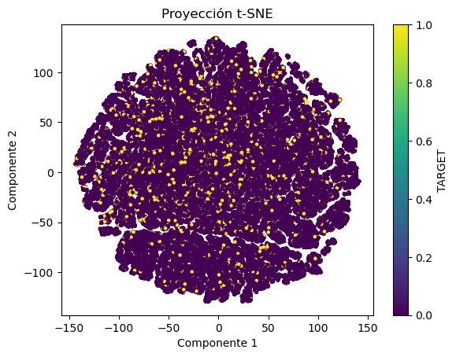

```python
plt.scatter(embedded_data[:, 0], embedded_data[:, 1], c=y_train, cmap='viridis', s=5)

plt.colorbar(label='TARGET')

# Títulos y etiquetas
plt.title('Proyección t-SNE')
plt.xlabel('Componente 1')
plt.ylabel('Componente 2')
plt.show()
```

El resultado del t-SNE muestra una nube mezclada sin separación clara al predecir la variable TARGET (variable objetivo), significa que las características utilizadas no permiten diferenciar adecuadamente entre las dos clases [0, 1]. Esto sugiere que el conjunto de datos carece de patrones relevantes o que la representación de las características no captura bien las relaciones necesarias para distinguir las categorías. Incluir esta técnica en el proyecto no aportaría valor, ya que no respalda la interpretación ni mejora la comprensión del comportamiento de la variable objetivo.

También comentar que me llevó realizar la reducción de variables por T-SNE unos 25 minutos, esto da lugar a un coste computacionalmente alto. Resulta otro motivo por el que no optaremos a implementar esta técnica.

### PCA

```python
%%time
pca_2c = PCA(n_components=2)
pca_2c.fit(X_train_scaled.reset_index(drop=True))
pca_array = pca_2c.transform(X_train_scaled)
```

```
CPU times: total: 1.14 s
Wall time: 332 ms
```

```python
pca_array
```

```
array([[ 8.95760572,  2.07907971],
       [ 0.22748656,  0.23573291],
       [-1.63887571,  2.95802727],
       ...,
       [-0.1365266 , -5.97305579],
       [-1.75328374,  3.77899326],
       [-1.63248895,  1.44551535]])
```

```python
pca_2c.components_
```

```
array([[ 6.07116254e-04,  1.30829004e-01,  1.31226666e-01,
         1.30122542e-01,  4.75409195e-02,  4.73814434e-02,
         4.62893939e-02, -8.00071592e-02,  6.18721409e-02,
         2.70831394e-02,  8.88059510e-03,  3.21756054e-02,
         1.83161295e-01,  1.82334880e-01,  1.82915194e-01,
         1.12625774e-01,  1.14998795e-01,  1.14705443e-01,
         8.20711357e-02,  8.34733802e-02,  8.36442876e-02,
        -9.01473537e-03,  1.21760872e-01,  1.21379675e-01,
         1.20152995e-01,  1.53866727e-01,  1.56365116e-01,
         1.56324388e-01,  1.47889365e-02,  9.44571668e-02,
         9.25775838e-02,  9.43713982e-02,  2.01828228e-01,
         2.01944712e-01,  1.99987800e-01, -5.12220878e-04,
         1.06861698e-01, -8.68972605e-02,  1.03796375e-02,
         7.11304434e-04, -3.07915337e-02, -2.04196417e-03,
         3.92769637e-02,  2.07458216e-01,  2.04246720e-01,
         2.07799885e-01,  1.33197814e-01,  1.26804377e-01,
         1.34039072e-01,  2.08990865e-01,  2.05617801e-01,
         2.08996173e-01,  8.75372324e-02, -8.60084977e-02,
        -1.00950004e-02, -1.62605913e-03,  1.66041942e-01,
         1.67201937e-01,  1.66841895e-01,  1.59848378e-02,
         1.77855436e-02,  1.75431461e-02,  2.06388525e-01,
         8.60616892e-02, -8.31694451e-02, -1.70028796e-02,
        -1.61869403e-02,  2.80110647e-03,  6.90303884e-04,
         1.18529728e-02,  5.66780680e-04,  1.68271054e-03,
        -3.11844153e-03, -2.77496062e-04, -6.95481939e-03,
         7.47861768e-03,  7.17708129e-04, -9.97268247e-04,
        -2.90034795e-03, -6.71147639e-04,  8.86238803e-04,
         1.60938348e-04, -6.93815516e-03, -4.80601669e-03,
        -7.04458848e-03, -4.74441163e-03,  2.96686305e-02,
         2.26929221e-02,  2.46157809e-02, -7.27573018e-03,
        -5.36309863e-03,  2.25310749e-02, -1.13303927e-03,
        -9.83970859e-04,  4.96016062e-03, -4.96016062e-03,
         4.13477007e-03, -4.13477007e-03,  1.09160800e-03,
        -1.08920132e-03, -3.25639512e-04,  2.13617375e-02,
         1.37186848e-02, -5.89437483e-03, -1.52045512e-02,
         2.03531256e-02, -2.22739259e-03, -6.05203927e-04,
         6.52480270e-04,  1.89209543e-04, -6.80876482e-05,
         2.06314558e-04, -3.10749610e-03, -2.97454434e-03,
         5.51430281e-03,  2.73828234e-03, -1.15629145e-03,
         4.35366942e-03,  1.07428800e-03, -1.70365394e-03,
```

[output cut: 63 more lines]

```
         6.24945776e-02,  4.27982523e-05,  1.76736831e-01,
         7.30916782e-02,  1.08366454e-03, -3.59654431e-02,
         3.59654431e-02,  4.26948993e-02,  1.42585015e-03,
         5.39306326e-02,  6.15933221e-02, -2.12749488e-04,
         1.92821163e-04, -9.01018370e-04, -7.03205259e-04,
        -2.13142108e-03,  1.49311778e-03,  4.18675022e-03,
        -2.50735523e-02,  9.39854751e-02,  1.74922681e-01,
         1.42617092e-01,  5.31807519e-02, -7.34388968e-04,
         1.07038742e-03, -3.94372516e-04,  5.55454116e-02,
         6.34952735e-03, -7.21703417e-04, -2.96241544e-03,
         3.52735888e-02, -9.25018964e-04, -1.23710563e-01,
        -7.92837056e-04,  4.86441612e-03,  8.47506680e-04,
         7.39091106e-03, -1.53451902e-04,  2.69944293e-03,
         3.60154392e-03, -4.14901527e-03,  5.97573560e-04,
         2.74774405e-03]])
```

Vamos a ver que componente pertenece a cada variable, se categorizarán según el tamaño de su coeficiente

```python
components = pca_2c.components_
component_names = [f'Component {i+1}' for i in range(2)]
df_components = pd.DataFrame(components.T, columns=component_names, index=X_train_scaled.columns.values)

df_components.style.apply(f_aux.highlight_max, props='color:black;background-color:deepskyblue', axis=1)
# utilizo una función auxiliar para resaltar los valores máximos en cada componente
```

|  | Component 1 | Component 2 |
| --- | --- | --- |
| SK_ID_CURR | 0.000607 | -0.001415 |
| COMMONAREA_AVG | 0.130829 | 0.011496 |
| COMMONAREA_MEDI | 0.131227 | 0.011649 |
| COMMONAREA_MODE | 0.130123 | 0.011707 |
| NONLIVINGAPARTMENTS_AVG | 0.047541 | -0.028945 |
| NONLIVINGAPARTMENTS_MEDI | 0.047381 | -0.028574 |
| NONLIVINGAPARTMENTS_MODE | 0.046289 | -0.026985 |
| FONDKAPREMONT_MODE_Desconocido | -0.080007 | 0.218217 |
| FONDKAPREMONT_MODE_reg oper account | 0.061872 | -0.186638 |
| FONDKAPREMONT_MODE_reg oper spec account | 0.027083 | -0.057277 |
| FONDKAPREMONT_MODE_not specified | 0.008881 | -0.046607 |
| FONDKAPREMONT_MODE_org spec account | 0.032176 | -0.032535 |
| LIVINGAPARTMENTS_MEDI | 0.183161 | 0.057944 |
| LIVINGAPARTMENTS_AVG | 0.182335 | 0.057947 |
| LIVINGAPARTMENTS_MODE | 0.182915 | 0.056510 |
| FLOORSMIN_MODE | 0.112626 | 0.024359 |
| FLOORSMIN_AVG | 0.114999 | 0.019694 |
| FLOORSMIN_MEDI | 0.114705 | 0.020135 |
| YEARS_BUILD_MODE | 0.082071 | 0.083654 |
| YEARS_BUILD_MEDI | 0.083473 | 0.078966 |
| YEARS_BUILD_AVG | 0.083644 | 0.078922 |
| OWN_CAR_AGE | -0.009015 | 0.028066 |
| LANDAREA_MEDI | 0.121761 | 0.048260 |
| LANDAREA_AVG | 0.121380 | 0.048106 |
| LANDAREA_MODE | 0.120153 | 0.046726 |
| BASEMENTAREA_MODE | 0.153867 | 0.083397 |
| BASEMENTAREA_AVG | 0.156365 | 0.083788 |
| BASEMENTAREA_MEDI | 0.156324 | 0.084230 |
| EXT_SOURCE_1 | 0.014789 | -0.083400 |
| NONLIVINGAREA_AVG | 0.094457 | -0.048527 |

[output cut: 145 more lines]

Es interesante ver como se han agrupado las variables, a priori, variables que consideramos importantes como (NAME_INCOME_TYPE), (CNT_CHILDREN), (OWN_CAR_AGE), (OCUPATION_TYPE), (CNT_FAM_MEMBERS) se agruparon en el componente 2 mientras que otras que también son importantes como el tipo de préstamo (NAME_CONTRACT_TYPE) o la cantidad de dinero prestada (AMT_CREDIT), o incluso la cantidad de ingreso del cliente (AMT_INCOME_TOTAL) se agruparon en el componente 1.

Aún viendo este tipo de agrupaciones de las variables, no utilizaremos el PCA en nuestro modelo final con dimensiones muy reducidas, en nuestro caso las variables no están muy relacionadas entre sí (análisis visto en el notebook 02) y por tanto la varianza explicada con pocos componentes es muy baja. Definitivamente no es un método adecuado en casos como el nuestro.

Vamos a comprobar la explicabilidad de la varianza:

```python
# Varianza explicada con solo 2 componentes:
pca_2c.explained_variance_ratio_.sum()
```

```
np.float64(0.14798109446935936)
```

Como podemos observar, la varianza explicada con 2 componentes es del 14.79%. Vamos a comprobar la varianza explicada con más de 2 componentes.

```
Varianza explicada por 2 components: 0.14798
Varianza explicada por 3 components: 0.18302
Varianza explicada por 4 components: 0.21029
Varianza explicada por 5 components: 0.23063
Varianza explicada por 6 components: 0.24856
Varianza explicada por 7 components: 0.26610
Varianza explicada por 8 components: 0.28269
Varianza explicada por 9 components: 0.29890
Varianza explicada por 10 components: 0.31372
Varianza explicada por 11 components: 0.32830
Varianza explicada por 12 components: 0.34243
Varianza explicada por 13 components: 0.35576
Varianza explicada por 14 components: 0.36869
Varianza explicada por 15 components: 0.38111
Varianza explicada por 16 components: 0.39312
Varianza explicada por 17 components: 0.40375
Varianza explicada por 18 components: 0.41428
Varianza explicada por 19 components: 0.42460
Varianza explicada por 20 components: 0.43419
Varianza explicada por 21 components: 0.44366
Varianza explicada por 22 components: 0.45225
Varianza explicada por 23 components: 0.46080
Varianza explicada por 24 components: 0.46891
Varianza explicada por 25 components: 0.47694
Varianza explicada por 26 components: 0.48482
Varianza explicada por 27 components: 0.49249
Varianza explicada por 28 components: 0.50010
Varianza explicada por 29 components: 0.50769
Varianza explicada por 30 components: 0.51525
Varianza explicada por 31 components: 0.52252
Varianza explicada por 32 components: 0.52969
Varianza explicada por 33 components: 0.53666
Varianza explicada por 34 components: 0.54361
Varianza explicada por 35 components: 0.55054
Varianza explicada por 36 components: 0.55741
Varianza explicada por 37 components: 0.56426
Varianza explicada por 38 components: 0.57111
Varianza explicada por 39 components: 0.57782
Varianza explicada por 40 components: 0.58444
Varianza explicada por 41 components: 0.59099
```

[output cut: 19 more lines]

```
Varianza explicada por 61 components: 0.71188
Varianza explicada por 62 components: 0.71765
Varianza explicada por 63 components: 0.72340
Varianza explicada por 64 components: 0.72915
Varianza explicada por 65 components: 0.73490
Varianza explicada por 66 components: 0.74064
Varianza explicada por 67 components: 0.74637
Varianza explicada por 68 components: 0.75209
Varianza explicada por 69 components: 0.75780
Varianza explicada por 70 components: 0.76351
Varianza explicada por 71 components: 0.76921
Varianza explicada por 72 components: 0.77492
Varianza explicada por 73 components: 0.78061
Varianza explicada por 74 components: 0.78630
Varianza explicada por 75 components: 0.79197
```

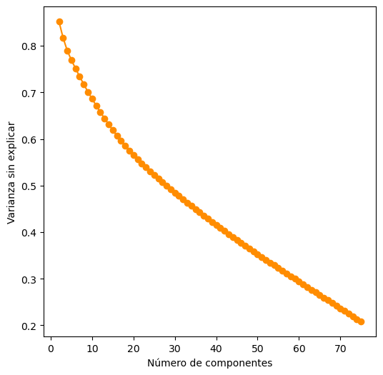

```python
ve_list = []
vne_list = []
n_comp = range(2,76)

for n in n_comp:
    pca = PCA(n_components=n)
    pca.fit(X_train_scaled.reset_index(drop=True))
    ve = pca.explained_variance_ratio_.sum()
    ve_list.append(ve)
    vne = 1-ve
    vne_list.append(vne)
    print(f'Varianza explicada por {n} components: {ve:.5f}')

plt.figure(figsize=(6, 6))
plt.plot(n_comp, vne_list, '-o', color='darkorange')
plt.xlabel(f'Número de componentes')
plt.ylabel('Varianza sin explicar')
plt.show()
```

Aún añadiendo hasta 75 componentes, no logramos obtener un resultado por el que valga la pena reducir la dimensionalidad.

Igualmente y con el objetivo de practicar y aprender, antes de pasar al siguiente método graficaré la distribución del dataframe en 2 dimensiones, discriminando por la variable objetivo

```python
principalDf = pd.DataFrame(data=pca_array, columns=['PC 1', 'PC 2'])
pcaDf = pd.concat([principalDf, y_train.reset_index(drop=True)], axis = 1)
pcaDf.head()
```

|  | PC 1 | PC 2 | TARGET |
| --- | --- | --- | --- |
| 0 | 8.957606 | 2.079080 | 0 |
| 1 | 0.227487 | 0.235733 | 0 |
| 2 | -1.638876 | 2.958027 | 0 |
| 3 | 6.594642 | -1.277740 | 0 |
| 4 | -1.610537 | 2.480488 | 0 |

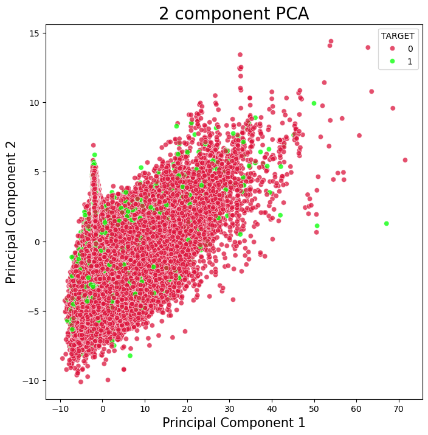

```python
fig, ax = plt.subplots(figsize=(8,8))
sns.scatterplot(data=pcaDf, x='PC 1', y='PC 2', hue='TARGET', alpha=0.75, palette=['crimson','lime'])
ax.set_xlabel('Principal Component 1', fontsize = 15)
ax.set_ylabel('Principal Component 2', fontsize = 15)
ax.set_title('2 component PCA', fontsize = 20)
plt.show()
```

Los puntos en la visualización no muestran patrones o agrupamientos distinguibles, las clases no están separadas claramente. Además como vimos antes, la varianza explicada es muy baja con 2 componentes. Como comentamos anteriormente, no es un buen método para nuestro caso.

```python
dump(pca_2c, '../models/pca_2componentes.joblib')
```

```
['../models/pca_2componentes.joblib']
```

He estado investigando sobre el formato de guardado de modelos y he llegado a la conclusión de que los guardaré en formato .joblib en vez de en formato .pickle como se comentó en clase. Este formato presenta un mayor rendimiento para objetos grandes, especialmente matrices NumPy. Utiliza técnicas de compresión más eficientes y permite paralelización.

### K-means

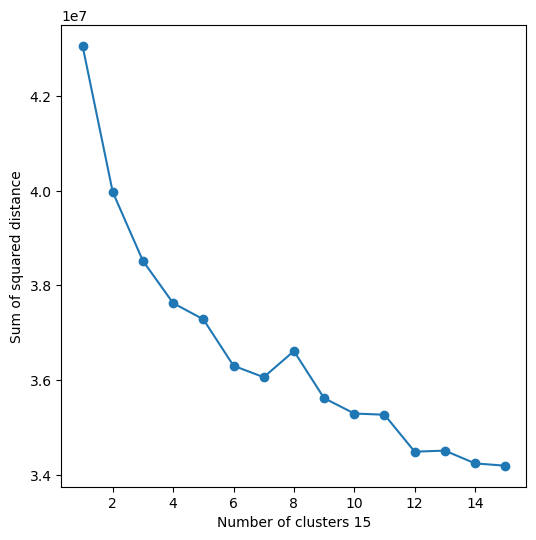

```
CPU times: total: 2min 24s
Wall time: 27.8 s
```

```python
%%time
f_aux.k_means_search(X_train_scaled, 15)
```

Vemos un patrón interesante al realizar la reducción por K-Means, Se aprecia un "codo" alrededor de 𝑘 =4, donde la disminución del SSE deja de ser tan significativa.

Vamos a analizar la calidad de los clusters para ver si sería una buena idea reducir dimensionalidad usando KMeans como un método de preprocesamiento.

```python
for k in range(2, 6):  # Probar diferentes números de clusters
    kmeans = KMeans(n_clusters=k, random_state=seed)
    kmeans.fit(X_train_scaled)
    labels = kmeans.labels_

    silhouette_avg = silhouette_score(X_train_scaled, labels)
    calinski_harabasz = calinski_harabasz_score(X_train_scaled, labels)

    print(f"k = {k} -> Silueta: {silhouette_avg:.2f}, Calinski-Harabasz: {calinski_harabasz:.2f}")
```

```
k = 2 -> Silueta: 0.28, Calinski-Harabasz: 18968.53
k = 3 -> Silueta: 0.04, Calinski-Harabasz: 13670.11
k = 4 -> Silueta: 0.04, Calinski-Harabasz: 12059.97
k = 5 -> Silueta: 0.04, Calinski-Harabasz: 9750.81
```

**Coeficiente de Silueta**:

- [0.7, 1]: Clusters muy compactos y bien separados.
- [0.5, 0.7]: Buena estructura de clustering.
- [0.25, 0.5]: Los clusters se solapan moderadamente.
- < 0.25: Los clusters son malos o no están bien definidos.

**Índice de Calinski-Harabasz**:

- Valores más altos significan que los clusters son más compactos y están mejor separados.

Observamos con las métricas de calidad de los clusters que no sería una buena opción reducir la dimensionalidad de nuestros datos. Pues cuando pasamos de 2 a 3 clusters se nota que no están bien definidos según la silhouette score y el coeficiente de Calinski-Harabasz disminuye considerablemente. Pensabamos que 𝑘 =4 era un número óptimo de clusters y acabamos viendo que no es el caso.

## Feature Selection

### Árbol

Voy a incluir una variable random que ayudará a delimitar que variables son más o menos importantes.

```python
X_train_tec['random_feature'] = np.random.rand(len(X_train_tec))
X_test_tec['random_feature'] = np.random.rand(len(X_test_tec))
```

```python
%%time
clf = RandomForestClassifier(n_estimators=300
                             ,criterion='gini'
                             ,max_depth=10
                             ,random_state=seed)
clf.fit(X_train_tec, y_train)
```

```
CPU times: total: 2min 4s
Wall time: 2min 4s
```

```
RandomForestClassifier(max_depth=10, n_estimators=300, random_state=12354)
```

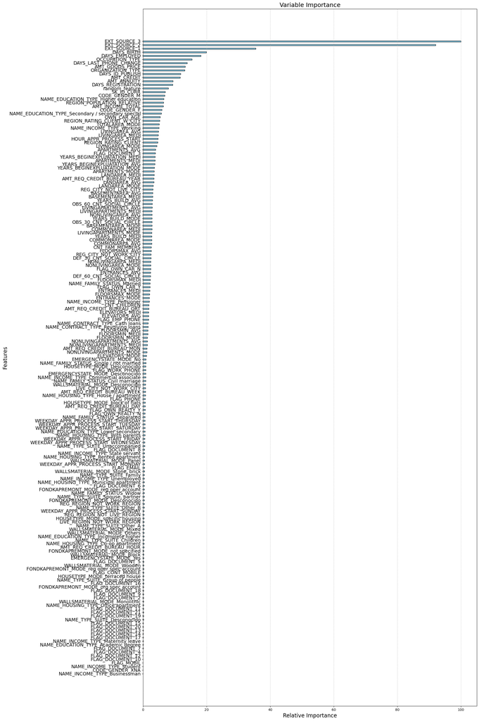

```python
# Hacer las importancias relativas al máximo
feature_importance = clf.feature_importances_
feature_importance = 100.0 * (feature_importance / feature_importance.max())

# Ordenar los índices según las importancias
sorted_idx = np.argsort(feature_importance)

# Crear posiciones con mayor separación
bar_width = 0.5  # Altura de las barras
pos = np.arange(sorted_idx.shape[0]) * 1.5  # Incrementa el espaciado entre barras

# Configuración del gráfico
plt.figure(figsize=(20, 30))  # Tamaño grande para evitar solapamientos
plt.barh(pos, feature_importance[sorted_idx], align='center', height=bar_width, color='skyblue', edgecolor='black')
plt.yticks(pos, X_train_tec.keys()[sorted_idx], fontsize=14)  # Tamaño más grande para las etiquetas


# Configuración de los ejes y título
plt.xlabel('Relative Importance', fontsize=16)
plt.ylabel('Features', fontsize=16)
plt.title('Variable Importance', fontsize=18)

# Añadir líneas de referencia opcionales
plt.grid(axis='x', linestyle='--', alpha=0.7)

# Ajustar automáticamente los espacios
plt.tight_layout()
plt.show()
```

```python
# Eliminar la columna 'random_feature' de ambos conjuntos de datos
X_train_tec = X_train_tec.drop(columns=['random_feature'], errors='ignore')
X_test_tec = X_test_tec.drop(columns=['random_feature'], errors='ignore')

# Re-entrenar el modelo con los datos sin la columna 'random_feature'
clf.fit(X_train_tec, y_train)
```

```
RandomForestClassifier(max_depth=10, n_estimators=300, random_state=12354)
```

Al observar el resultado, vemos como nuestra variable (random_feature) el modelo le da mucha importancia, esto da a pensar que las variables originales que tienen una importancia menor o similar a 'random_feature' podrían considerarse ruido o irrelevantes.

Seguiré con mi análisis y comentaré las conclusiones al final del mismo.

### Regresiones con regularización

#### Regularización Ridge

```python
sel_ridge = SelectFromModel(LogisticRegression(C=1, penalty='l2'), threshold = 0.05)
sel_ridge.fit(X_train_scaled, y_train)
```

```
SelectFromModel(estimator=LogisticRegression(C=1), threshold=0.05)
```

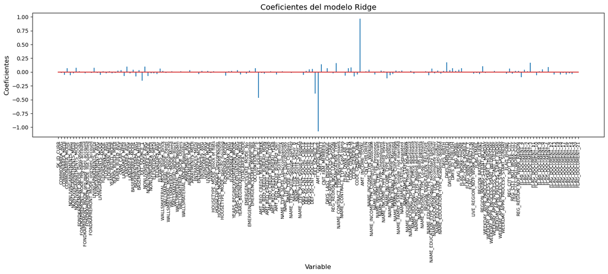

```python
# Coeficientes del modelo
# ==============================================================================

df_coeficientes = pd.DataFrame(
    {'predictor': X_train_scaled.columns,
     'coef': sel_ridge.estimator_.coef_.flatten()}
)

fig, ax = plt.subplots(figsize=(16, 6))  # Ampliamos la altura de la figura
ax.stem(df_coeficientes.predictor, df_coeficientes.coef, markerfmt=' ')
plt.xticks(
    rotation=90,  # Rotación completa para maximizar legibilidad
    ha='center',  # Centrar etiquetas respecto al eje
    size=8  # Ajustar tamaño de las etiquetas
)
plt.tight_layout(pad=3.0)  # Añadir espacio adicional en los márgenes
ax.set_xlabel('Variable', fontsize=12)
ax.set_ylabel('Coeficientes', fontsize=12)
ax.set_title('Coeficientes del modelo Ridge', fontsize=14)
plt.subplots_adjust(bottom=0.4)  # Espacio extra en la parte inferior para las etiquetas
plt.show()
```

```python
sel_ridge.get_support()
selected_feat = X_train_scaled.columns[sel_ridge.get_support()]
selected_feat
```

```
Index(['COMMONAREA_MEDI', 'COMMONAREA_MODE', 'NONLIVINGAPARTMENTS_AVG',
       'NONLIVINGAPARTMENTS_MODE', 'LIVINGAPARTMENTS_MEDI', 'LANDAREA_MEDI',
       'LANDAREA_AVG', 'BASEMENTAREA_AVG', 'EXT_SOURCE_1', 'NONLIVINGAREA_AVG',
       'NONLIVINGAREA_MODE', 'ELEVATORS_MODE', 'FLOORSMAX_MODE',
       'OCCUPATION_TYPE', 'EXT_SOURCE_3', 'DEF_30_CNT_SOCIAL_CIRCLE',
       'EXT_SOURCE_2', 'AMT_GOODS_PRICE', 'AMT_ANNUITY',
       'DAYS_LAST_PHONE_CHANGE', 'ORGANIZATION_TYPE', 'FLAG_OWN_CAR_Y',
       'FLAG_OWN_CAR_N', 'CODE_GENDER_M', 'CODE_GENDER_F', 'AMT_CREDIT',
       'NAME_INCOME_TYPE_Student', 'NAME_INCOME_TYPE_Businessman',
       'NAME_EDUCATION_TYPE_Higher education',
       'NAME_EDUCATION_TYPE_Secondary / secondary special', 'DAYS_EMPLOYED',
       'DAYS_ID_PUBLISH', 'FLAG_WORK_PHONE', 'REGION_RATING_CLIENT_W_CITY',
       'REG_CITY_NOT_LIVE_CITY', 'FLAG_DOCUMENT_4', 'FLAG_DOCUMENT_3',
       'FLAG_DOCUMENT_10', 'FLAG_DOCUMENT_6'],
      dtype='object')
```

```python
print('total features: {}'.format((X_train_scaled.shape[1])))
print('selected features: {}'.format(len(selected_feat)))
```

```
total features: 175
selected features: 39
```

```python
# variables eliminadas:
X_train_scaled.columns[~sel_ridge.get_support()]
```

```
Index(['SK_ID_CURR', 'COMMONAREA_AVG', 'NONLIVINGAPARTMENTS_MEDI',
       'FONDKAPREMONT_MODE_Desconocido', 'FONDKAPREMONT_MODE_reg oper account',
       'FONDKAPREMONT_MODE_reg oper spec account',
       'FONDKAPREMONT_MODE_not specified',
       'FONDKAPREMONT_MODE_org spec account', 'LIVINGAPARTMENTS_AVG',
       'LIVINGAPARTMENTS_MODE',
       ...
       'FLAG_DOCUMENT_12', 'FLAG_DOCUMENT_13', 'FLAG_DOCUMENT_19',
       'FLAG_DOCUMENT_18', 'FLAG_DOCUMENT_17', 'FLAG_DOCUMENT_16',
       'FLAG_DOCUMENT_15', 'FLAG_DOCUMENT_14', 'FLAG_DOCUMENT_20',
       'FLAG_DOCUMENT_21'],
      dtype='object', length=136)
```

Realizaré la regularización Lasso y Boruta y comentaré las conclusiones de todos a la vez

#### Regularización Lasso

```python
sel_lasso = SelectFromModel(LogisticRegression(C=1, penalty='l1',
                                          solver='liblinear'), threshold = 0.05)
sel_lasso.fit(X_train_scaled, y_train)
```

```
SelectFromModel(estimator=LogisticRegression(C=1, penalty='l1',
                                             solver='liblinear'),
                threshold=0.05)
```

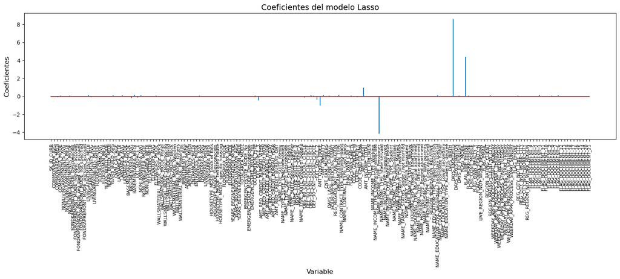

```python
# Coeficientes del modelo
# ==============================================================================

df_coeficientes = pd.DataFrame(
    {'predictor': X_train_scaled.columns,
     'coef': sel_lasso.estimator_.coef_.flatten()}
)

fig, ax = plt.subplots(figsize=(16, 6))  # Ampliamos la altura de la figura
ax.stem(df_coeficientes.predictor, df_coeficientes.coef, markerfmt=' ')
plt.xticks(
    rotation=90,  # Rotación completa para maximizar legibilidad
    ha='center',  # Centrar etiquetas respecto al eje
    size=8  # Ajustar tamaño de las etiquetas
)
plt.tight_layout(pad=3.0)  # Añadir espacio adicional en los márgenes
ax.set_xlabel('Variable', fontsize=12)
ax.set_ylabel('Coeficientes', fontsize=12)
ax.set_title('Coeficientes del modelo Lasso', fontsize=14)
plt.subplots_adjust(bottom=0.4)  # Espacio extra en la parte inferior para las etiquetas
plt.show()
```

```python
sel_lasso.get_support()
selected_feat_lasso = X_train_scaled.columns[sel_lasso.get_support()]
selected_feat_lasso
```

```
Index(['COMMONAREA_MEDI', 'COMMONAREA_MODE', 'NONLIVINGAPARTMENTS_MODE',
       'LIVINGAPARTMENTS_MEDI', 'LIVINGAPARTMENTS_AVG',
       'LIVINGAPARTMENTS_MODE', 'FLOORSMIN_AVG', 'YEARS_BUILD_MEDI',
       'YEARS_BUILD_AVG', 'LANDAREA_MEDI', 'LANDAREA_AVG', 'BASEMENTAREA_AVG',
       'BASEMENTAREA_MEDI', 'EXT_SOURCE_1', 'NONLIVINGAREA_AVG',
       'NONLIVINGAREA_MODE', 'ELEVATORS_MODE', 'ENTRANCES_MEDI',
       'ENTRANCES_AVG', 'FLOORSMAX_MODE', 'OCCUPATION_TYPE', 'EXT_SOURCE_3',
       'OBS_60_CNT_SOCIAL_CIRCLE', 'OBS_30_CNT_SOCIAL_CIRCLE', 'EXT_SOURCE_2',
       'AMT_GOODS_PRICE', 'AMT_ANNUITY', 'DAYS_LAST_PHONE_CHANGE',
       'ORGANIZATION_TYPE', 'FLAG_OWN_CAR_Y', 'CODE_GENDER_F', 'AMT_CREDIT',
       'NAME_INCOME_TYPE_Pensioner', 'NAME_INCOME_TYPE_Unemployed',
       'NAME_FAMILY_STATUS_Married',
       'NAME_EDUCATION_TYPE_Secondary / secondary special', 'DAYS_EMPLOYED',
       'DAYS_ID_PUBLISH', 'FLAG_EMP_PHONE', 'FLAG_WORK_PHONE',
       'REGION_RATING_CLIENT_W_CITY', 'REG_CITY_NOT_LIVE_CITY',
       'FLAG_DOCUMENT_3', 'FLAG_DOCUMENT_6'],
      dtype='object')
```

```python
print('total features: {}'.format((X_train_scaled.shape[1])))
print('selected features: {}'.format(len(selected_feat_lasso)))
```

```
total features: 175
selected features: 44
```

```python
# A eliminar según Lasso:
X_train_scaled.columns[~sel_lasso.get_support()]
```

```
Index(['SK_ID_CURR', 'COMMONAREA_AVG', 'NONLIVINGAPARTMENTS_AVG',
       'NONLIVINGAPARTMENTS_MEDI', 'FONDKAPREMONT_MODE_Desconocido',
       'FONDKAPREMONT_MODE_reg oper account',
       'FONDKAPREMONT_MODE_reg oper spec account',
       'FONDKAPREMONT_MODE_not specified',
       'FONDKAPREMONT_MODE_org spec account', 'FLOORSMIN_MODE',
       ...
       'FLAG_DOCUMENT_12', 'FLAG_DOCUMENT_13', 'FLAG_DOCUMENT_19',
       'FLAG_DOCUMENT_18', 'FLAG_DOCUMENT_17', 'FLAG_DOCUMENT_16',
       'FLAG_DOCUMENT_15', 'FLAG_DOCUMENT_14', 'FLAG_DOCUMENT_20',
       'FLAG_DOCUMENT_21'],
      dtype='object', length=131)
```

```python
# A eliminar según Ridge:
X_train_scaled.columns[~sel_ridge.get_support()]
```

```
Index(['SK_ID_CURR', 'COMMONAREA_AVG', 'NONLIVINGAPARTMENTS_MEDI',
       'FONDKAPREMONT_MODE_Desconocido', 'FONDKAPREMONT_MODE_reg oper account',
       'FONDKAPREMONT_MODE_reg oper spec account',
       'FONDKAPREMONT_MODE_not specified',
       'FONDKAPREMONT_MODE_org spec account', 'LIVINGAPARTMENTS_AVG',
       'LIVINGAPARTMENTS_MODE',
       ...
       'FLAG_DOCUMENT_12', 'FLAG_DOCUMENT_13', 'FLAG_DOCUMENT_19',
       'FLAG_DOCUMENT_18', 'FLAG_DOCUMENT_17', 'FLAG_DOCUMENT_16',
       'FLAG_DOCUMENT_15', 'FLAG_DOCUMENT_14', 'FLAG_DOCUMENT_20',
       'FLAG_DOCUMENT_21'],
      dtype='object', length=136)
```

### Boruta

```python
%%time

# sampling in proportion to y labels
rf = RandomForestClassifier(n_jobs=-1, max_depth=10)  # num leaves

# define Boruta feature selection method
np.int = np.int32
np.float = np.float64
np.bool = np.bool_

feat_selector = BorutaPy(rf, n_estimators='auto', verbose=2, random_state=seed)

# find all relevant features - 5 features should be selected
feat_selector.fit(X_train_tec.values, y_train.values)

# check selected features - first 5 features are selected
feat_selector.support_

# check ranking of features
feat_selector.ranking_
```

[output not shown]

[output cut: 83 more lines]

```
Rejected: 	157
Iteration: 	32 / 100
Confirmed: 	16
Tentative: 	0
Rejected: 	159


BorutaPy finished running.

Iteration: 	33 / 100
Confirmed: 	16
Tentative: 	0
Rejected: 	159
CPU times: total: 1h 15min 48s
Wall time: 7min 23s
```

```
array([  7,  50,  48,  51,  74,  77,  74,  96, 111, 128, 123, 135,  34,
        45,  43,  72,  67,  69,  39,  38,  40,  10,  28,  26,  27,  41,
        31,  35,   1,  47,  58,  53,  63,  60,  64, 104,  88,  78, 120,
       130, 129, 108, 142,  21,  25,  19,  61,  61,  59,  13,  16,  13,
        70,  74, 132, 114,  55,  33,  46,  23,  22,  23,  11,  65,  67,
       133,   1,   1,  83,  78, 116,  86,  29,  65, 108, 102, 145, 126,
       126, 119, 124, 135,  43,  36,  53,  31,   1,   1,   1,  42,   1,
        15, 117,   1,  53,  56,  30,  36,   1,   1, 157,   1,   8,  57,
         6,  82,  20,  97,  91, 148, 157, 157,  48,  85,  71,  99, 114,
        83, 105, 143,  98,  81, 118,   2,   1,   3, 121,  90, 152,   1,
         1,   1,   1, 157,  18,  76, 131,  93,  95, 126, 112,   5,   4,
       107, 102, 101,  92,  99, 106, 114,  88,  12,  16,  80, 110, 157,
       122, 133,   8, 144, 157, 138,  93, 153,  86, 157, 150, 139, 137,
       151, 139, 147, 149, 146, 141])
```

```python
selected_feat_boruta = X_train_tec.columns[feat_selector.support_]
selected_feat_boruta
```

```
Index(['EXT_SOURCE_1', 'OCCUPATION_TYPE', 'EXT_SOURCE_3', 'EXT_SOURCE_2',
       'AMT_GOODS_PRICE', 'AMT_ANNUITY', 'DAYS_LAST_PHONE_CHANGE',
       'ORGANIZATION_TYPE', 'CODE_GENDER_M', 'CODE_GENDER_F', 'AMT_CREDIT',
       'NAME_EDUCATION_TYPE_Higher education', 'DAYS_BIRTH', 'DAYS_EMPLOYED',
       'DAYS_REGISTRATION', 'DAYS_ID_PUBLISH'],
      dtype='object')
```

## Selección de las variables:

Teniendo en cuenta nuestro Dataset, no es fácil seleccionar variables. Pues como vimos aplicando los siguientes métodos (RandomForest, Ridge, Lasso y Boruta), cada método nos sugiere variables distintas, aunque algunas coinciden. Personalmente, no tendré en cuenta el modelo de RandomForest ya que al añadir la variable aleatoria, vimos como el modelo le daba mucha importancia. Por tanto, sus resultados no los consideraré relevantes para la selección de variables.

De igual manera, después de haber aplicado los 3 métodos que vamos a utilizar para la selección de variables, regresión logística con Ridge, la misma con Lasso y por último Boruta. Me decantaré principalmente por las variables seleccionadas por el método Boruta y aquí expondré mis razones:

- Boruta seleccionó 16 variables de las 175, lo que reduce considerablemente el coste computacional a la hora de implementar y poner en producción nuestro modelo.
- Boruta evalúa la importancia de cada característica comparándola con características aleatorias. Esto es útil para identificar características relevantes que otros métodos pueden pasar por alto.
- A diferencia de métodos como Ridge o Lasso, Boruta no requiere que el modelo se ajuste a una suposición matemática (como la linealidad).
- Al basarse en el concepto de "permutación aleatoria", Boruta es menos sensible a los valores atípicos y a la colinealidad.
- Puede identificar variables que tienen una relación interactiva importante, algo que métodos lineales como Ridge y Lasso no pueden capturar directamente.

```python
selected_feat_boruta = list(selected_feat_boruta)

# Concatenamos las columnas seleccionadas por Boruta con las columnas adicionales
X_train_t = X_train_tec[selected_feat_boruta + ['NAME_EDUCATION_TYPE_Incomplete higher',
                                                'NAME_EDUCATION_TYPE_Lower secondary',
                                                'NAME_EDUCATION_TYPE_Academic degree',
                                                'NAME_EDUCATION_TYPE_Secondary / secondary special']]

X_test_t = X_test_tec[selected_feat_boruta + ['NAME_EDUCATION_TYPE_Incomplete higher',
                                              'NAME_EDUCATION_TYPE_Lower secondary',
                                              'NAME_EDUCATION_TYPE_Academic degree',
                                              'NAME_EDUCATION_TYPE_Secondary / secondary special']]
```

## Probar el modelo con las nuevas variables seleccionadas

Vamos a ver que tal se comportan diferentes métricas con las variables que hemos seleccionado de nuestro Dataset

```python
%%time

classifiers = [
    RandomForestClassifier(),
    GradientBoostingClassifier()
    ]

for classifier in classifiers:
    pipe = Pipeline(steps=[('classifier', classifier)])
    pipe.fit(X_train_t, y_train)
    print(classifier)
    print("model score: %.3f" % pipe.score(X_test_t, y_test))
```

```
RandomForestClassifier()
model score: 0.919
GradientBoostingClassifier()
model score: 0.920
CPU times: total: 2min 15s
Wall time: 2min 16s
```

```python
%%time

clf = GradientBoostingClassifier(
              learning_rate=0.1,  max_depth=12,
              min_weight_fraction_leaf=0.02, n_estimators=130,
              random_state=seed,
              verbose=1)
clf.fit(X_train_t,y_train)
```

```
      Iter       Train Loss   Remaining Time
         1           0.5510            3.39m
         2           0.5432            3.44m
         3           0.5372            3.38m
         4           0.5323            3.35m
         5           0.5280            3.29m
         6           0.5245            3.24m
         7           0.5216            3.20m
         8           0.5189            3.23m
         9           0.5167            3.25m
        10           0.5146            3.24m
        20           0.5021            3.01m
        30           0.4961            2.74m
        40           0.4923            2.48m
        50           0.4899            2.24m
        60           0.4877            1.97m
        70           0.4862            1.72m
        80           0.4848            1.45m
        90           0.4835            1.17m
       100           0.4824           53.02s
CPU times: total: 3min 56s
Wall time: 3min 57s
```

```
GradientBoostingClassifier(max_depth=12, min_weight_fraction_leaf=0.02,
                           n_estimators=130, random_state=12354, verbose=1)
```

Observamos unos scores altos, que se refieren al acuraccy del modelo. Además la disminución del Train Loss es una buena señal de que el modelo está aprendiendo bien.

```python
%%time
clf_2= RandomForestClassifier(n_estimators=300
                             ,criterion='gini'
                             ,max_depth=5
                             ,random_state=seed)
clf_2.fit(X_train_t, y_train)
```

```
CPU times: total: 55.1 s
Wall time: 55.2 s
```

```
RandomForestClassifier(max_depth=5, n_estimators=300, random_state=12354)
```

```python
# Realizar predicciones
pred_test = clf_2.predict_proba(X_test_t)
pred_train = clf_2.predict_proba(X_train_t)
```

#### Curva ROC

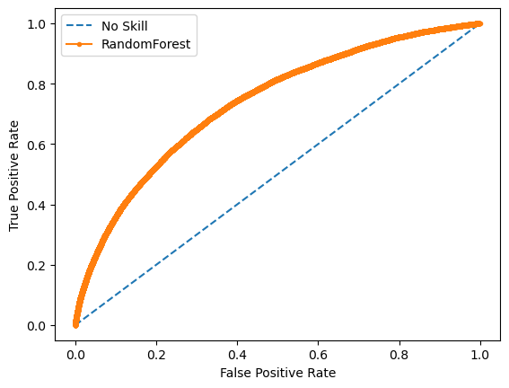

```python
# keep probabilities for the positive outcome only
yhat_train = pred_train[:, 1]
# calculate roc curves
fpr, tpr, thresholds = roc_curve(y_train, yhat_train)
# plot the roc curve for the model
plt.plot([0,1], [0,1], linestyle='--', label='No Skill')
plt.plot(fpr, tpr, marker='.', label='RandomForest')
# axis labels
plt.xlabel('False Positive Rate')
plt.ylabel('True Positive Rate')
plt.legend()
# show the plot
plt.show()
```

```python
# calculate AUC
auc_curve = roc_auc_score(y_train, yhat_train)
print('AUC: %.3f' % auc_curve)
```

```
AUC: 0.737
```

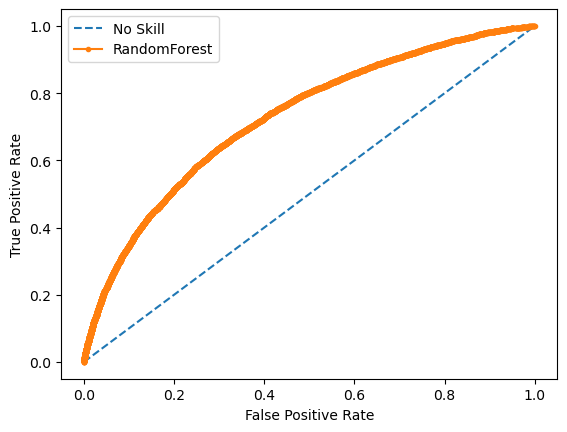

```python
# keep probabilities for the positive outcome only
yhat = pred_test[:, 1]
# calculate roc curves
fpr, tpr, thresholds = roc_curve(y_test, yhat)
# plot the roc curve for the model
plt.plot([0,1], [0,1], linestyle='--', label='No Skill')
plt.plot(fpr, tpr, marker='.', label='RandomForest')
# axis labels
plt.xlabel('False Positive Rate')
plt.ylabel('True Positive Rate')
plt.legend()
# show the plot
plt.show()
```

```python
# calculate AUC
auc_curve = roc_auc_score(y_test, yhat)
print('AUC: %.3f' % auc_curve)
```

```
AUC: 0.727
```

## Creo un pipeline en el que se encapsule el Feature Processing

Después de verificar que las variables seleccionadas para nuestros modelos son correctas y proporcionan buenas métricas de scoring, voy a crear un pipeline donde se encapsulen todos los tratamientos realizados.

La idea es crear un pipeline donde se realicen secuencialmente todos los pasos del procesamiento, para que cuando ingresemos el test o cualquier otro dataset, solo tenga que introducirlo y aplicar ese procesamiento.

Esta será la única vez que dejaré varias funciones definidas en el notebook, ya que se pueden encontrar en mi .py pero quiero dejarla expuesta aquí para que se entienda el proceso.

Esta primera función es para seleccionar las variables de nuestro algoritmo Boruta, esta función es extrapolable a otros Datasets, solo habría que cambiar las columnas seleccionadas en 'selected_columns' dentro de la función. Además, añadí un argumento extra en el que se pueden introducir columnas nuevas en caso de querer añadir más.

```python
def feature_selection(df, add=[]):
    """
    ----------------------------------------------------------------------------------------------------------
    Función feature_selection:
    ----------------------------------------------------------------------------------------------------------
    - Funcionamiento: Recibe un DataFrame y un opcional de columnas extras a incluir. Devuelve un DataFrame
      con solo las columnas seleccionadas, además de las columnas adicionales en caso de haberse introducido.
    - Inputs:
        - df: DataFrame de Pandas del que se seleccionarán las columnas
        - add: argumento opcional en el que se pueden incluir más columnas para seleccionar
    - Return: DataFrame de pandas con las columnas seleccionadas según el feature selection aplicado.
    """
    # Columnas a seleccionar
    selected_columns = [
        'EXT_SOURCE_1', 'OCCUPATION_TYPE', 'EXT_SOURCE_3', 'EXT_SOURCE_2',
        'AMT_GOODS_PRICE', 'AMT_ANNUITY', 'DAYS_LAST_PHONE_CHANGE',
        'ORGANIZATION_TYPE', 'CODE_GENDER', 'AMT_CREDIT',
        'NAME_EDUCATION_TYPE', 'DAYS_BIRTH',
        'DAYS_EMPLOYED', 'DAYS_REGISTRATION', 'DAYS_ID_PUBLISH',
    ]

    # Si se pasan columnas adicionales, las agregamos a la lista de selección
    if add:
        selected_columns += add

    # Filtramos solo las columnas seleccionadas que existen en el DataFrame
    df_new = df[selected_columns]

    return df_new
```

En esta segunda función se van a aplicar todos los tratamientos realizados a las variables, en nuestro caso los encodings y el escalado, los encodings se realizarán como anteriormente he mencionado al hacerlos manualmente, por su número de categorías. El escalado es opcional en la función.

```python
def preprocessing(df, y=None, scale=True):
    """
    ----------------------------------------------------------------------------------------------------------
    Función preprocessing:
    ----------------------------------------------------------------------------------------------------------
    - Funcionamiento: Función que recibe un dataframe y realiza el preprocesamiento en base a los parámetros
      que el usuario elija. Aplica One Hot Encoding para variables con < 10 categorías, Target Encoding para
      variables con entre 10 y 20 categorías, y CatBoost Encoding para variables con > 20 categorías.
    - Inputs:
        - df: DataFrame de pandas sobre el que se generará el objeto preprocessor
        - y: la variable objetivo (opcional, pero necesaria si se usa TargetEncoding o CatBoostEncoder)
        - scale: indica si se debe aplicar StandardScaler a las variables numéricas.
    - Output: devuelve un objeto preprocessor listo para ser instanciado.
    """
    if scale:
        numeric_transformer = Pipeline(steps=[('scaler', StandardScaler())])
    else:
        numeric_transformer = Pipeline(steps=[('pass', 'passthrough')])

    # Creamos los diferentes pipelines para los encodings
    onehot_transformer = OneHotEncoder(sparse_output=False)
    mean_transformer = TargetEncoder()
    catboost_transformer = CatBoostEncoder()

    # Detectar tipos de variables
    df_bool, df_cat, df_num = f_aux.tipos_vars(df, False)

    # Variables numéricas
    numeric_features = df.select_dtypes(include=['int64', 'float64']).drop(df_bool, axis=1).columns
    # Variables booleanas
    boolean_features = df[df_bool].columns

    # Variables categóricas
    categorical_features = df.select_dtypes(include=['object']).drop(df_bool, axis=1).columns

    # Inicializamos listas para las columnas de cada tipo de encoding
    ohe_features = []
    te_features = []
    catboost_features = []

    # Revisar las variables categóricas y asignar el tipo de encoding
    for col in categorical_features:
        n_categories = len(df[col].unique())
        if n_categories < 10:
            ohe_features.append(col)
        elif 10 <= n_categories <= 20:
            te_features.append(col)
        else:
            catboost_features.append(col)

    # Crear el preprocesador con ColumnTransformer
    preprocessor = ColumnTransformer(
        transformers=[
            ('num', numeric_transformer, numeric_features),
            ('ohe', onehot_transformer, ohe_features),
            ('te', mean_transformer, te_features),
            ('catboost', catboost_transformer, catboost_features),
            ('bool', 'passthrough', boolean_features)
        ],
        remainder='passthrough',
        verbose_feature_names_out=False
    ).set_output(transform="pandas")

    return preprocessor
```

```python
features_sel = feature_selection(df_loan_train)
```

```python
preprocessor = preprocessing(features_sel, y_train)

# Ahora podemos aplicar el preprocesador a los datos de entrenamiento
X_train_transformed = preprocessor.fit_transform(features_sel, y_train)
```

```python
X_train_transformed
```

|  | EXT_SOURCE_1 | EXT_SOURCE_3 | EXT_SOURCE_2 | AMT_GOODS_PRICE | AMT_ANNUITY | DAYS_LAST_PHONE_CHANGE | AMT_CREDIT | DAYS_BIRTH | DAYS_EMPLOYED | DAYS_REGISTRATION | DAYS_ID_PUBLISH | CODE_GENDER_F | CODE_GENDER_M | CODE_GENDER_XNA | NAME_EDUCATION_TYPE_Academic degree | NAME_EDUCATION_TYPE_Higher education | NAME_EDUCATION_TYPE_Incomplete higher | NAME_EDUCATION_TYPE_Lower secondary | NAME_EDUCATION_TYPE_Secondary / secondary special | OCCUPATION_TYPE | ORGANIZATION_TYPE |
| --- | --- | --- | --- | --- | --- | --- | --- | --- | --- | --- | --- | --- | --- | --- | --- | --- | --- | --- | --- | --- | --- |
| 0 | -1.678138 | 0.112233 | -0.168837 | -0.726658 | -0.937733 | 0.973145 | -0.817483 | 0.881576 | -0.457787 | 0.160148 | 1.535604 | 0.0 | 1.0 | 0.0 | 0.0 | 1.0 | 0.0 | 0.0 | 0.0 | 0.105925 | 0.080729 |
| 1 | -1.949661 | -2.633310 | -0.163856 | 0.785442 | -0.027317 | 0.727427 | 0.569687 | 0.124285 | -0.458134 | -0.497687 | -0.658402 | 0.0 | 1.0 | 0.0 | 0.0 | 0.0 | 0.0 | 0.0 | 1.0 | 0.111213 | 0.080729 |
| 2 | 0.011352 | -0.021539 | 0.540079 | -0.202301 | 1.620740 | 0.913834 | -0.245186 | -0.287700 | -0.465697 | 0.946936 | 1.442171 | 1.0 | 0.0 | 0.0 | 0.0 | 0.0 | 0.0 | 0.0 | 1.0 | 0.105925 | 0.080729 |
| 3 | 0.011352 | 0.112233 | 0.995094 | -1.092489 | -1.403023 | -0.814670 | -1.153089 | -1.346991 | -0.459697 | -1.804834 | -0.768400 | 1.0 | 0.0 | 0.0 | 0.0 | 0.0 | 0.0 | 0.0 | 1.0 | 0.096676 | 0.040365 |
| 4 | 0.011352 | 0.112233 | 0.851431 | 0.370834 | 0.236037 | 1.165605 | 0.853833 | 0.309197 | -0.474201 | -0.324991 | -0.876411 | 1.0 | 0.0 | 0.0 | 0.0 | 0.0 | 0.0 | 0.0 | 1.0 | 0.091564 | 0.080729 |
| ... | ... | ... | ... | ... | ... | ... | ... | ... | ... | ... | ... | ... | ... | ... | ... | ... | ... | ... | ... | ... | ... |
| 246003 | -1.752675 | 0.719139 | 0.204172 | -1.092489 | -1.403023 | -1.416258 | -1.153089 | 0.184089 | -0.513212 | 1.147183 | -0.957916 | 0.0 | 1.0 | 0.0 | 0.0 | 0.0 | 0.0 | 0.0 | 1.0 | 0.063535 | 0.079255 |
| 246004 | 0.011352 | 0.356460 | 1.106272 | 0.383028 | 2.939991 | -2.784052 | 0.334304 | 0.102059 | -0.476054 | -1.281066 | -0.686233 | 0.0 | 1.0 | 0.0 | 0.0 | 1.0 | 0.0 | 0.0 | 0.0 | 0.063535 | 0.060278 |
| 246005 | 1.065944 | -0.583842 | 0.950775 | -0.994934 | -1.180305 | 0.858154 | -0.839141 | -0.990457 | 2.131977 | -1.782679 | -0.337683 | 1.0 | 0.0 | 0.0 | 0.0 | 0.0 | 0.0 | 0.0 | 1.0 | 0.064772 | 0.053818 |
| 246006 | -0.513216 | 1.433439 | -0.316069 | -0.190107 | -0.187066 | -0.942977 | -0.187048 | 0.345400 | -0.470260 | 1.266763 | -1.510559 | 0.0 | 1.0 | 0.0 | 0.0 | 0.0 | 0.0 | 0.0 | 1.0 | 0.105925 | 0.093677 |
| 246007 | 1.160975 | 0.506016 | 1.411047 | -0.909573 | -0.670037 | -1.939167 | -0.885611 | 0.615092 | -0.488124 | 0.306996 | -1.024180 | 1.0 | 0.0 | 0.0 | 0.0 | 0.0 | 0.0 | 0.0 | 1.0 | 0.049149 | 0.075282 |

246008 rows × 21 columns

```python
f_aux.preprocessing(f_aux.feature_selection(df_loan_train), y_train, scale=True).fit_transform(f_aux.feature_selection(df_loan_train), y_train)
```

|  | EXT_SOURCE_1 | EXT_SOURCE_3 | EXT_SOURCE_2 | AMT_GOODS_PRICE | AMT_ANNUITY | DAYS_LAST_PHONE_CHANGE | AMT_CREDIT | DAYS_BIRTH | DAYS_EMPLOYED | DAYS_REGISTRATION | DAYS_ID_PUBLISH | CODE_GENDER_F | CODE_GENDER_M | CODE_GENDER_XNA | NAME_EDUCATION_TYPE_Academic degree | NAME_EDUCATION_TYPE_Higher education | NAME_EDUCATION_TYPE_Incomplete higher | NAME_EDUCATION_TYPE_Lower secondary | NAME_EDUCATION_TYPE_Secondary / secondary special | OCCUPATION_TYPE | ORGANIZATION_TYPE |
| --- | --- | --- | --- | --- | --- | --- | --- | --- | --- | --- | --- | --- | --- | --- | --- | --- | --- | --- | --- | --- | --- |
| 0 | -1.678138 | 0.112233 | -0.168837 | -0.726658 | -0.937733 | 0.973145 | -0.817483 | 0.881576 | -0.457787 | 0.160148 | 1.535604 | 0.0 | 1.0 | 0.0 | 0.0 | 1.0 | 0.0 | 0.0 | 0.0 | 0.105925 | 0.080729 |
| 1 | -1.949661 | -2.633310 | -0.163856 | 0.785442 | -0.027317 | 0.727427 | 0.569687 | 0.124285 | -0.458134 | -0.497687 | -0.658402 | 0.0 | 1.0 | 0.0 | 0.0 | 0.0 | 0.0 | 0.0 | 1.0 | 0.111213 | 0.080729 |
| 2 | 0.011352 | -0.021539 | 0.540079 | -0.202301 | 1.620740 | 0.913834 | -0.245186 | -0.287700 | -0.465697 | 0.946936 | 1.442171 | 1.0 | 0.0 | 0.0 | 0.0 | 0.0 | 0.0 | 0.0 | 1.0 | 0.105925 | 0.080729 |
| 3 | 0.011352 | 0.112233 | 0.995094 | -1.092489 | -1.403023 | -0.814670 | -1.153089 | -1.346991 | -0.459697 | -1.804834 | -0.768400 | 1.0 | 0.0 | 0.0 | 0.0 | 0.0 | 0.0 | 0.0 | 1.0 | 0.096676 | 0.040365 |
| 4 | 0.011352 | 0.112233 | 0.851431 | 0.370834 | 0.236037 | 1.165605 | 0.853833 | 0.309197 | -0.474201 | -0.324991 | -0.876411 | 1.0 | 0.0 | 0.0 | 0.0 | 0.0 | 0.0 | 0.0 | 1.0 | 0.091564 | 0.080729 |
| ... | ... | ... | ... | ... | ... | ... | ... | ... | ... | ... | ... | ... | ... | ... | ... | ... | ... | ... | ... | ... | ... |
| 246003 | -1.752675 | 0.719139 | 0.204172 | -1.092489 | -1.403023 | -1.416258 | -1.153089 | 0.184089 | -0.513212 | 1.147183 | -0.957916 | 0.0 | 1.0 | 0.0 | 0.0 | 0.0 | 0.0 | 0.0 | 1.0 | 0.063535 | 0.079255 |
| 246004 | 0.011352 | 0.356460 | 1.106272 | 0.383028 | 2.939991 | -2.784052 | 0.334304 | 0.102059 | -0.476054 | -1.281066 | -0.686233 | 0.0 | 1.0 | 0.0 | 0.0 | 1.0 | 0.0 | 0.0 | 0.0 | 0.063535 | 0.060278 |
| 246005 | 1.065944 | -0.583842 | 0.950775 | -0.994934 | -1.180305 | 0.858154 | -0.839141 | -0.990457 | 2.131977 | -1.782679 | -0.337683 | 1.0 | 0.0 | 0.0 | 0.0 | 0.0 | 0.0 | 0.0 | 1.0 | 0.064772 | 0.053818 |
| 246006 | -0.513216 | 1.433439 | -0.316069 | -0.190107 | -0.187066 | -0.942977 | -0.187048 | 0.345400 | -0.470260 | 1.266763 | -1.510559 | 0.0 | 1.0 | 0.0 | 0.0 | 0.0 | 0.0 | 0.0 | 1.0 | 0.105925 | 0.093677 |
| 246007 | 1.160975 | 0.506016 | 1.411047 | -0.909573 | -0.670037 | -1.939167 | -0.885611 | 0.615092 | -0.488124 | 0.306996 | -1.024180 | 1.0 | 0.0 | 0.0 | 0.0 | 0.0 | 0.0 | 0.0 | 1.0 | 0.049149 | 0.075282 |

246008 rows × 21 columns

Y así tenemos el preprocesamiento listo en una sola línea, cabe destacar que necesitamos separar en train y test antes de ejecutarlo ya que uno de los argumentos necesarios en nuestra función es `y_train` necesario para realizar el Target Encoding y el CatBoost encoding.

## Exportación de los datos

```python
df_loan_train_processed = f_aux.preprocessing(f_aux.feature_selection(df_loan_train), y_train, scale=True).fit_transform(f_aux.feature_selection(df_loan_train), y_train)

df_loan_train_processed['TARGET'] = df_loan_train['TARGET']
df_loan_train_processed
```

|  | EXT_SOURCE_1 | EXT_SOURCE_3 | EXT_SOURCE_2 | AMT_GOODS_PRICE | AMT_ANNUITY | DAYS_LAST_PHONE_CHANGE | AMT_CREDIT | DAYS_BIRTH | DAYS_EMPLOYED | DAYS_REGISTRATION | DAYS_ID_PUBLISH | CODE_GENDER_F | CODE_GENDER_M | CODE_GENDER_XNA | NAME_EDUCATION_TYPE_Academic degree | NAME_EDUCATION_TYPE_Higher education | NAME_EDUCATION_TYPE_Incomplete higher | NAME_EDUCATION_TYPE_Lower secondary | NAME_EDUCATION_TYPE_Secondary / secondary special | OCCUPATION_TYPE | ORGANIZATION_TYPE | TARGET |
| --- | --- | --- | --- | --- | --- | --- | --- | --- | --- | --- | --- | --- | --- | --- | --- | --- | --- | --- | --- | --- | --- | --- |
| 0 | -1.678138 | 0.112233 | -0.168837 | -0.726658 | -0.937733 | 0.973145 | -0.817483 | 0.881576 | -0.457787 | 0.160148 | 1.535604 | 0.0 | 1.0 | 0.0 | 0.0 | 1.0 | 0.0 | 0.0 | 0.0 | 0.105925 | 0.080729 | 0 |
| 1 | -1.949661 | -2.633310 | -0.163856 | 0.785442 | -0.027317 | 0.727427 | 0.569687 | 0.124285 | -0.458134 | -0.497687 | -0.658402 | 0.0 | 1.0 | 0.0 | 0.0 | 0.0 | 0.0 | 0.0 | 1.0 | 0.111213 | 0.080729 | 0 |
| 2 | 0.011352 | -0.021539 | 0.540079 | -0.202301 | 1.620740 | 0.913834 | -0.245186 | -0.287700 | -0.465697 | 0.946936 | 1.442171 | 1.0 | 0.0 | 0.0 | 0.0 | 0.0 | 0.0 | 0.0 | 1.0 | 0.105925 | 0.080729 | 0 |
| 3 | 0.011352 | 0.112233 | 0.995094 | -1.092489 | -1.403023 | -0.814670 | -1.153089 | -1.346991 | -0.459697 | -1.804834 | -0.768400 | 1.0 | 0.0 | 0.0 | 0.0 | 0.0 | 0.0 | 0.0 | 1.0 | 0.096676 | 0.040365 | 0 |
| 4 | 0.011352 | 0.112233 | 0.851431 | 0.370834 | 0.236037 | 1.165605 | 0.853833 | 0.309197 | -0.474201 | -0.324991 | -0.876411 | 1.0 | 0.0 | 0.0 | 0.0 | 0.0 | 0.0 | 0.0 | 1.0 | 0.091564 | 0.080729 | 0 |
| ... | ... | ... | ... | ... | ... | ... | ... | ... | ... | ... | ... | ... | ... | ... | ... | ... | ... | ... | ... | ... | ... | ... |
| 246003 | -1.752675 | 0.719139 | 0.204172 | -1.092489 | -1.403023 | -1.416258 | -1.153089 | 0.184089 | -0.513212 | 1.147183 | -0.957916 | 0.0 | 1.0 | 0.0 | 0.0 | 0.0 | 0.0 | 0.0 | 1.0 | 0.063535 | 0.079255 | 0 |
| 246004 | 0.011352 | 0.356460 | 1.106272 | 0.383028 | 2.939991 | -2.784052 | 0.334304 | 0.102059 | -0.476054 | -1.281066 | -0.686233 | 0.0 | 1.0 | 0.0 | 0.0 | 1.0 | 0.0 | 0.0 | 0.0 | 0.063535 | 0.060278 | 0 |
| 246005 | 1.065944 | -0.583842 | 0.950775 | -0.994934 | -1.180305 | 0.858154 | -0.839141 | -0.990457 | 2.131977 | -1.782679 | -0.337683 | 1.0 | 0.0 | 0.0 | 0.0 | 0.0 | 0.0 | 0.0 | 1.0 | 0.064772 | 0.053818 | 0 |
| 246006 | -0.513216 | 1.433439 | -0.316069 | -0.190107 | -0.187066 | -0.942977 | -0.187048 | 0.345400 | -0.470260 | 1.266763 | -1.510559 | 0.0 | 1.0 | 0.0 | 0.0 | 0.0 | 0.0 | 0.0 | 1.0 | 0.105925 | 0.093677 | 0 |
| 246007 | 1.160975 | 0.506016 | 1.411047 | -0.909573 | -0.670037 | -1.939167 | -0.885611 | 0.615092 | -0.488124 | 0.306996 | -1.024180 | 1.0 | 0.0 | 0.0 | 0.0 | 0.0 | 0.0 | 0.0 | 1.0 | 0.049149 | 0.075282 | 0 |

246008 rows × 22 columns

```python
df_loan_test_processed = f_aux.preprocessing(f_aux.feature_selection(df_loan_test), y_test, scale=True).fit_transform(f_aux.feature_selection(df_loan_test), y_test)

df_loan_test_processed['TARGET'] = df_loan_test['TARGET']
df_loan_test_processed
```

|  | EXT_SOURCE_1 | EXT_SOURCE_3 | EXT_SOURCE_2 | AMT_GOODS_PRICE | AMT_ANNUITY | DAYS_LAST_PHONE_CHANGE | AMT_CREDIT | DAYS_BIRTH | DAYS_EMPLOYED | DAYS_REGISTRATION | DAYS_ID_PUBLISH | CODE_GENDER_F | CODE_GENDER_M | CODE_GENDER_XNA | NAME_EDUCATION_TYPE_Academic degree | NAME_EDUCATION_TYPE_Higher education | NAME_EDUCATION_TYPE_Incomplete higher | NAME_EDUCATION_TYPE_Lower secondary | NAME_EDUCATION_TYPE_Secondary / secondary special | OCCUPATION_TYPE | ORGANIZATION_TYPE | TARGET |
| --- | --- | --- | --- | --- | --- | --- | --- | --- | --- | --- | --- | --- | --- | --- | --- | --- | --- | --- | --- | --- | --- | --- |
| 0 | -1.720850 | -1.185928 | 0.260432 | -1.090780 | -1.333072 | -1.649991 | -1.152092 | 0.070213 | -0.473781 | 0.520795 | -0.687441 | 1.0 | 0.0 | 0.0 | 0.0 | 0.0 | 0.0 | 0.0 | 1.0 | 0.105239 | 0.080728 | 0 |
| 1 | 2.976193 | 0.057840 | 1.155696 | 3.405013 | 1.549496 | 0.175352 | 2.975147 | 0.302395 | -0.484440 | -0.734678 | -0.874760 | 1.0 | 0.0 | 0.0 | 0.0 | 1.0 | 0.0 | 0.0 | 0.0 | 0.066570 | 0.080728 | 0 |
| 2 | 0.015099 | -2.955404 | 0.527922 | 1.582394 | 0.739173 | -0.620372 | 1.706858 | 0.410808 | -0.492476 | 0.201972 | 1.582892 | 0.0 | 1.0 | 0.0 | 0.0 | 1.0 | 0.0 | 0.0 | 0.0 | 0.105239 | 0.080728 | 0 |
| 3 | 0.015099 | 0.364069 | 0.666992 | 0.634632 | 0.029206 | -0.573352 | 0.431876 | 0.152039 | -0.460008 | -0.029925 | -1.050827 | 1.0 | 0.0 | 0.0 | 0.0 | 0.0 | 0.0 | 0.0 | 1.0 | 0.105239 | 0.080728 | 0 |
| 4 | 0.622852 | 1.318719 | 0.289593 | -0.604749 | -0.787974 | -0.339457 | -0.705904 | -0.226833 | -0.463355 | -0.490606 | 1.599440 | 1.0 | 0.0 | 0.0 | 0.0 | 0.0 | 0.0 | 0.0 | 1.0 | 0.094891 | 0.080728 | 0 |
| ... | ... | ... | ... | ... | ... | ... | ... | ... | ... | ... | ... | ... | ... | ... | ... | ... | ... | ... | ... | ... | ... | ... |
| 61498 | 1.320061 | 1.063085 | 0.846886 | -0.143018 | 0.352400 | 0.575626 | -0.186608 | -0.353353 | -0.520362 | -1.745513 | 1.251278 | 1.0 | 0.0 | 0.0 | 0.0 | 1.0 | 0.0 | 0.0 | 0.0 | 0.066570 | 0.040981 | 0 |
| 61499 | -1.652298 | -1.281565 | 0.848938 | 0.987005 | 0.435302 | 0.615412 | 1.080912 | 1.383544 | -0.469525 | -0.944773 | 1.251278 | 1.0 | 0.0 | 0.0 | 0.0 | 0.0 | 0.0 | 0.0 | 1.0 | 0.064200 | 0.071399 | 0 |
| 61500 | -0.129339 | 1.655248 | 0.940783 | -0.811312 | -1.272298 | 1.157951 | -0.770668 | -1.079237 | 2.140210 | -0.842840 | -0.718551 | 1.0 | 0.0 | 0.0 | 0.0 | 0.0 | 0.0 | 0.0 | 1.0 | 0.066570 | 0.054736 | 0 |
| 61501 | 1.255212 | 0.119593 | -2.336288 | 1.898315 | 0.495765 | -0.528743 | 1.591964 | -0.932089 | 2.140210 | 0.012830 | 0.637030 | 1.0 | 0.0 | 0.0 | 0.0 | 0.0 | 0.0 | 0.0 | 1.0 | 0.066570 | 0.054731 | 0 |
| 61502 | -1.175332 | -0.323879 | 1.450214 | -0.847764 | -0.248486 | 0.879448 | -0.752307 | 1.405776 | -0.452844 | 1.073781 | 1.138092 | 1.0 | 0.0 | 0.0 | 0.0 | 1.0 | 0.0 | 0.0 | 0.0 | 0.094891 | 0.098079 | 0 |

61503 rows × 22 columns

```python
df_loan_train_processed.to_csv('../../data_loan_status/processed/df_loan_train_processed.csv', index=False)
df_loan_test_processed.to_csv('../../data_loan_status/processed/df_loan_test_processed.csv', index=False)
```